title: “Car Repair Analysis Report” author: “3조” output: html_document: toc: true toc_depth: 4 toc_float: true

# **Car Repair Analysis Report**

### Preview

**Purpose**

**차량 수리 비용 예측 모델**에 사용할 차종, 파손 유형, 색상, 연식이

수리비에 유의미한 영향을 미치는 변수인지 검정하기 위해 진행한 분석

| 변수 | 도장 (coating) | 판금수리(sheet_metal) | 탈착교환(exchange) | 비고 |
| --- | --- | --- | --- | --- |
| **차종(supercategory_name)** | True | True | True | 모든 변수의 P-value가 유의미하게 작음 |
| **파손유형(damage)** | True | True | True | 모든 변수의 P-value가 유의미하게 작음 |
| **색상(color)** | True | True | True | coating과 exchage가 유의미한 차이가 존재하는 색상 조합이 많음 |
| **연식(year)** | True | True | True | 모든 변수의 P-value가 유의미하게 작음 |

# 1. Data Definition

- https://www.aihub.or.kr/aihubdata/data/view.do?currMenu=115&topMenu=100

## 1-1. Package Prepare

```r
# install.packages("readxl")
# install.packages("nparcomp")
# install.packages("nortest")
# install.packages("dplyr")
# install.packages("pgirmess")
# install.packages("ggplot2")
# install.packages("gridExtra")

library(readxl)
library(nparcomp)
library(nortest)
library(dplyr)
library(pgirmess)
library(ggplot2)
library(gridExtra)
```

## 1-2. Data Load

```r
repair_car <- read.csv("repair_price.csv", header=T)
str(repair_car)
```

```
## 'data.frame':    232714 obs. of  8 variables:
##  $ category_id       : chr  "as-0000025" "as-0000025" "as-0000025" "as-0000027" ...
##  $ coating           : int  488500 488500 488500 496500 496500 496500 167500 167500 146250 131250 ...
##  $ sheet_metal       : int  175000 175000 175000 262500 262500 262500 75000 75000 50000 37500 ...
##  $ exchange          : int  145750 145750 145750 267750 267750 267750 45000 45000 29000 50250 ...
##  $ total             : int  1121128 1121128 1121128 1293228 1293228 1293228 380078 380078 282728 267178 ...
##  $ repair            : chr  "['Front door', 'Rear fender', 'Front bumper', 'Front fender']" "['Front door', 'Rear fender', 'Front bumper', 'Front fender']" "['Front door', 'Rear fender', 'Front bumper', 'Front fender']" "['Front door', 'Rear fender', 'Rear door', 'Rear bumper', 'Rocker panel']" .…
##  $ supercategory_name: chr  "Full-size car" "Full-size car" "Full-size car" "Mid-size car" ...
##  $ damage            : chr  "Separated" "Scratched" "Crushed" "Breakage" ...
```

```r
repair_car_cy <- read.csv("color_year_data.csv", header=T)
str(repair_car_cy)
```

```
## 'data.frame':    107209 obs. of  7 variables:
##  $ category_id: chr  "as-0000025" "as-0000027" "as-0000029" "as-0000034" ...
##  $ coating    : int  488500 496500 167500 146250 131250 282919 235044 186000 449047 506250 ...
##  $ sheet_metal: int  175000 262500 75000 50000 37500 109350 36450 1075000 75000 188000 ...
##  $ exchange   : int  145750 267750 45000 29000 50250 36690 58080 101500 207250 110000 ...
##  $ total      : int  1121128 1293228 380078 282728 267178 540037 421652 1473578 904275 962828 ...
##  $ year       : int  2016 2015 2017 2018 2017 2016 2017 2014 2016 2016 ...
##  $ color      : chr  "White" "Gray tone" "White" "Black" ...
```

## 1-3. Data Review

```r
head(repair_car)
```

```
##   category_id coating sheet_metal exchange   total
## 1  as-0000025  488500      175000   145750 1121128
## 2  as-0000025  488500      175000   145750 1121128
## 3  as-0000025  488500      175000   145750 1121128
## 4  as-0000027  496500      262500   267750 1293228
## 5  as-0000027  496500      262500   267750 1293228
## 6  as-0000027  496500      262500   267750 1293228
##                                                                      repair
## 1             ['Front door', 'Rear fender', 'Front bumper', 'Front fender']
## 2             ['Front door', 'Rear fender', 'Front bumper', 'Front fender']
## 3             ['Front door', 'Rear fender', 'Front bumper', 'Front fender']
## 4 ['Front door', 'Rear fender', 'Rear door', 'Rear bumper', 'Rocker panel']
## 5 ['Front door', 'Rear fender', 'Rear door', 'Rear bumper', 'Rocker panel']
## 6 ['Front door', 'Rear fender', 'Rear door', 'Rear bumper', 'Rocker panel']
##   supercategory_name    damage
## 1      Full-size car Separated
## 2      Full-size car Scratched
## 3      Full-size car   Crushed
## 4       Mid-size car  Breakage
## 5       Mid-size car Scratched
## 6       Mid-size car   Crushed
```

```r
head(repair_car_cy)
```

```
##   category_id coating sheet_metal exchange   total year     color
## 1  as-0000025  488500      175000   145750 1121128 2016     White
## 2  as-0000027  496500      262500   267750 1293228 2015 Gray tone
## 3  as-0000029  167500       75000    45000  380078 2017     White
## 4  as-0000034  146250       50000    29000  282728 2018     Black
## 5  as-0000037  131250       37500    50250  267178 2017     Black
## 6  as-0000040  282919      109350    36690  540037 2016     White
```

```r
repair_car$total <- repair_car$coating + repair_car$sheet_metal + repair_car$exchange
repair_car[repair_car$supercategory_name == "CityCar", "supercategory_name"] = "Compact car"
head(repair_car)
```

```
##   category_id coating sheet_metal exchange   total
## 1  as-0000025  488500      175000   145750  809250
## 2  as-0000025  488500      175000   145750  809250
## 3  as-0000025  488500      175000   145750  809250
## 4  as-0000027  496500      262500   267750 1026750
## 5  as-0000027  496500      262500   267750 1026750
## 6  as-0000027  496500      262500   267750 1026750
##                                                                      repair
## 1             ['Front door', 'Rear fender', 'Front bumper', 'Front fender']
## 2             ['Front door', 'Rear fender', 'Front bumper', 'Front fender']
## 3             ['Front door', 'Rear fender', 'Front bumper', 'Front fender']
## 4 ['Front door', 'Rear fender', 'Rear door', 'Rear bumper', 'Rocker panel']
## 5 ['Front door', 'Rear fender', 'Rear door', 'Rear bumper', 'Rocker panel']
## 6 ['Front door', 'Rear fender', 'Rear door', 'Rear bumper', 'Rocker panel']
##   supercategory_name    damage
## 1      Full-size car Separated
## 2      Full-size car Scratched
## 3      Full-size car   Crushed
## 4       Mid-size car  Breakage
## 5       Mid-size car Scratched
## 6       Mid-size car   Crushed
```

```r
repair_car_cy$total <- repair_car_cy$coating + repair_car_cy$sheet_metal + repair_car_cy$exchange
head(repair_car_cy)
```

```
##   category_id coating sheet_metal exchange   total year     color
## 1  as-0000025  488500      175000   145750  809250 2016     White
## 2  as-0000027  496500      262500   267750 1026750 2015 Gray tone
## 3  as-0000029  167500       75000    45000  287500 2017     White
## 4  as-0000034  146250       50000    29000  225250 2018     Black
## 5  as-0000037  131250       37500    50250  219000 2017     Black
## 6  as-0000040  282919      109350    36690  428959 2016     White
```

# 2. EDA & Statistical Test

## 2-1. 차종별 수리비용 차이가 존재하는가?

- 귀무가설 : 차종별 수리비용 차이가 존재하지 않는다.
- 대립가설 : 차종별 수리비용 차이가 존재한다.

### 2-1-1. Feature Review

- supercategory_name(차종) : Full-size car(대형), Mid-size car(중형), Compact car(소형)  
  *Compact car은 소형과 경형을 합쳐둔 것*
- total(총지불금액) = coating(도장공임) + sheet_metal(판금수리) + exchange(탈착교환)

**차종 변수 검토**

```r
table(repair_car$supercategory_name)
```

```
##
##   Compact car Full-size car  Mid-size car
##         64104         45106        123504
```

**차종별 차의 개수와 평균 수리비용 조회**

```r
mean_table <- repair_car %>% group_by(supercategory_name) %>%
                  summarise(mean_total = mean(total), mean_coating = mean(coating),
                            mean_sheet_metal = mean(sheet_metal), mean_exchange = mean(exchange),
                            count = n())
mean_table
```

```
## # A tibble: 3 × 6
##   supercategory_name mean_total mean_coating mean_sheet_metal mean_exchange
##   <chr>                   <dbl>        <dbl>            <dbl>         <dbl>
## 1 Compact car           325128.      152423.           60618.       112087.
## 2 Full-size car         571251.      263665.           97741.       209844.
## 3 Mid-size car          415185.      192738.           71341.       151106.
## # ℹ 1 more variable: count <int>
```

**항목별 수리비 변수 검토**

```r
print(summary(repair_car$total))
```

```
##    Min. 1st Qu.  Median    Mean 3rd Qu.    Max.
##       0  189000  313452  420627  515580 7102350
```

```r
print(summary(repair_car$coating))
```

```
##    Min. 1st Qu.  Median    Mean 3rd Qu.    Max.
##       0   96370  159500  195380  255434 4084300
```

```r
print(summary(repair_car$sheet_metal))
```

```
##    Min. 1st Qu.  Median    Mean 3rd Qu.    Max.
##       0       0   46143   73504  100000 2970000
```

```r
print(summary(repair_car$exchange))
```

```
##    Min. 1st Qu.  Median    Mean 3rd Qu.    Max.
##       0   61000   94250  151742  165240 4693300
```

=> max값이 너무 커 평균과 중앙값 차이가 많이 남 -> 보정 필요

### 2-1-2. 시각화

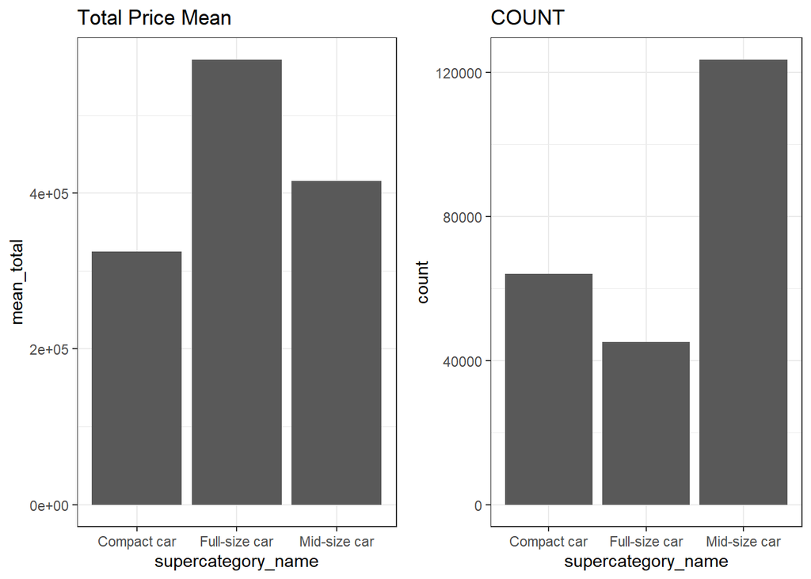

```r
# 차종에 따른 총 수리비용 평균과 분포 개수 확인 #
theme_set(theme_bw())
g1 <- ggplot(data = mean_table, aes(x=supercategory_name, y=mean_total)) + geom_col() +
  labs(title="Total Price Mean")
g2 <- ggplot(data = mean_table, aes(x=supercategory_name, y=count)) + geom_col() +
  labs(title="COUNT")
grid.arrange(g1, g2, ncol=2)
```

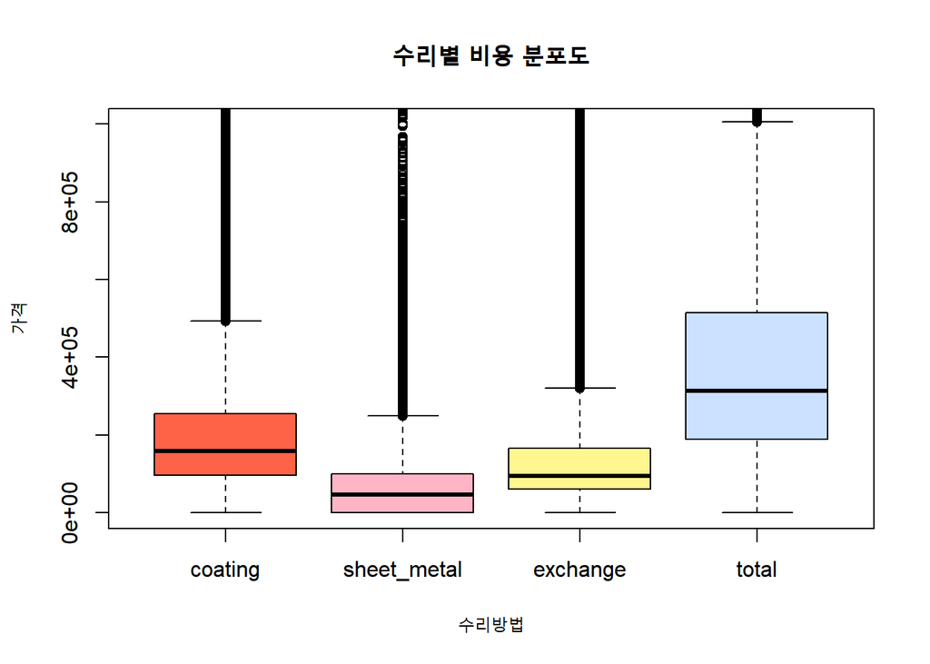

```r
boxplot(repair_car$coating, repair_car$sheet_metal, repair_car$exchange, repair_car$total,
        col=c("Tomato1", "Pink1", "Khaki1", "Light Steel Blue1"), main="수리별 비용 분포도",xlab="수리방법",ylab="가격",
        ylim=c(0, 1e+06), names=c("coating","sheet_metal","exchange", "total"))
```

### 2-1-3. 극단값 조정

```r
# 극단값 제거
repair_sqrt <- subset(repair_car, coating <= 5e+05 & sheet_metal <= 5e+05 & exchange <= 5e+05)

# 정규화 해주기
repair_sqrt <- transform(repair_sqrt, coating = sqrt(coating + 1))
repair_sqrt <- transform(repair_sqrt, sheet_metal = sqrt(sheet_metal + 1))
repair_sqrt <- transform(repair_sqrt, exchange = sqrt(exchange + 1))
repair_sqrt <- transform(repair_sqrt, total = sqrt(total + 1))

repair_sqrt %>% select("coating", "sheet_metal", "exchange", "total") %>% head(7)
```

```
##    coating sheet_metal exchange     total
## 1 698.9285    418.3312 381.7735  899.5838
## 2 698.9285    418.3312 381.7735  899.5838
## 3 698.9285    418.3312 381.7735  899.5838
## 4 704.6283    512.3485 517.4466 1013.2872
## 5 704.6283    512.3485 517.4466 1013.2872
## 6 704.6283    512.3485 517.4466 1013.2872
## 7 409.2689    273.8631 212.1344  536.1912
```

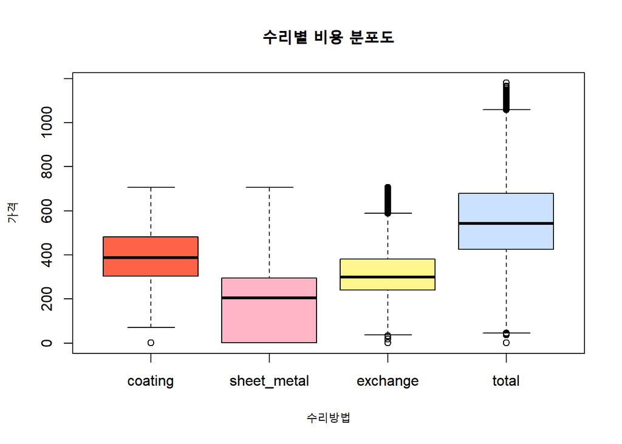

```r
boxplot(repair_sqrt$coating, repair_sqrt$sheet_metal, repair_sqrt$exchange, repair_sqrt$total,
        col=c("Tomato1", "Pink1", "Khaki1", "Light Steel Blue1"), main="수리별 비용 분포도",
        xlab="수리방법",ylab="가격", names=c("coating","sheet_metal","exchange", "total"))
```

### 2-1-4. Statistical Test

#### (1) 정규분포 확인

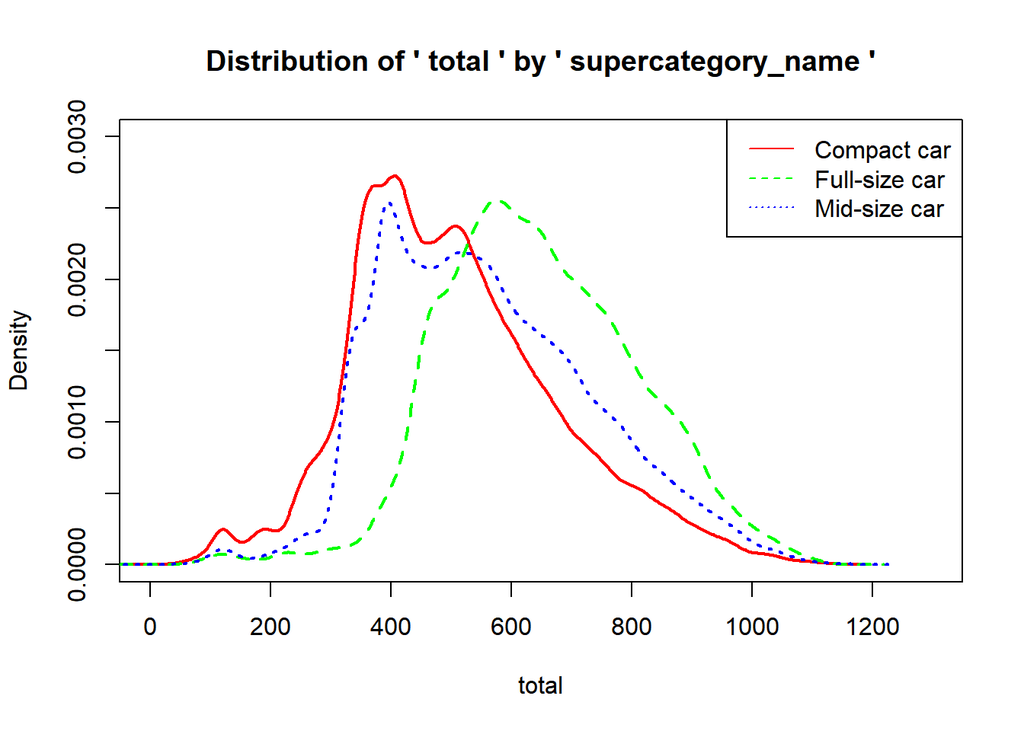

```r
moonBook::densityplot(total~supercategory_name, data=repair_sqrt)
```

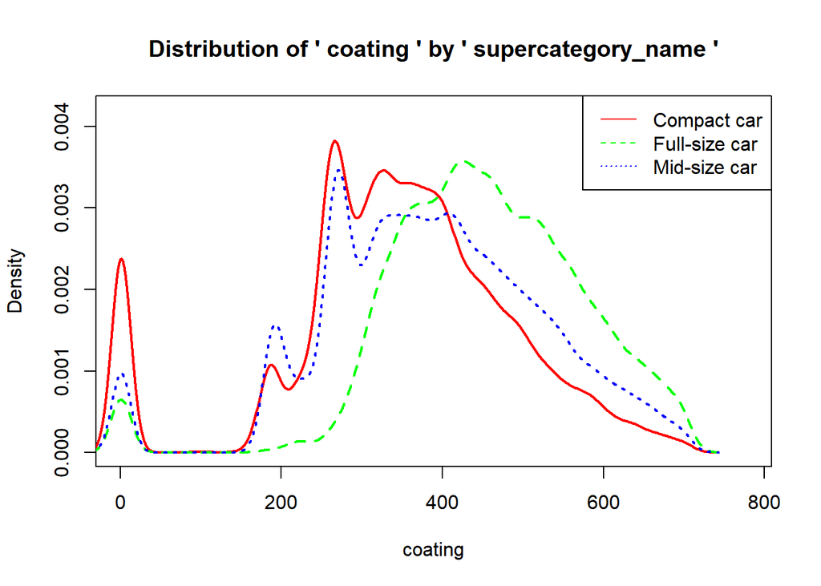

```r
moonBook::densityplot(coating~supercategory_name, data=repair_sqrt)
```

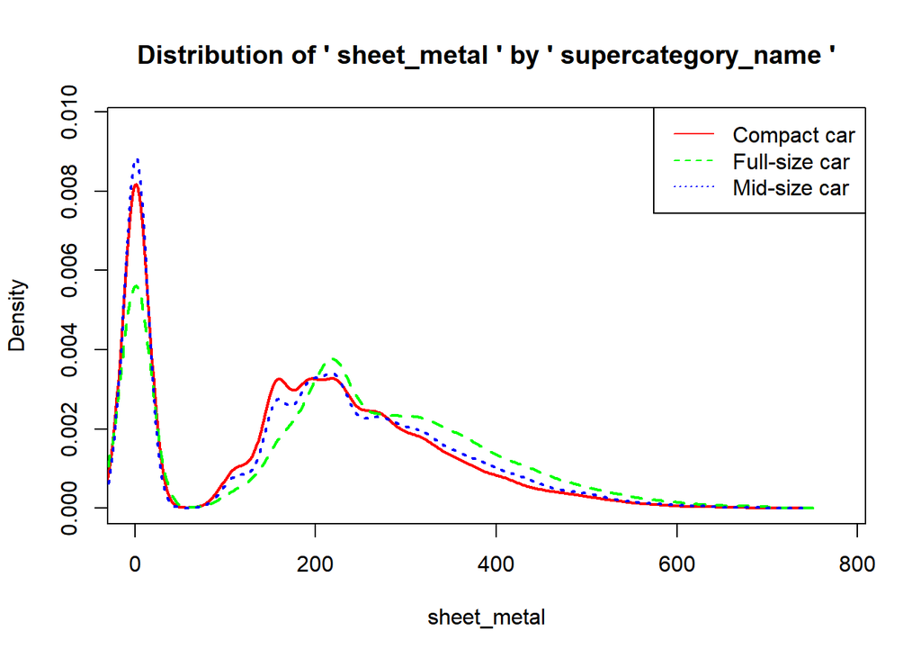

```r
moonBook::densityplot(sheet_metal~supercategory_name, data=repair_sqrt)
```

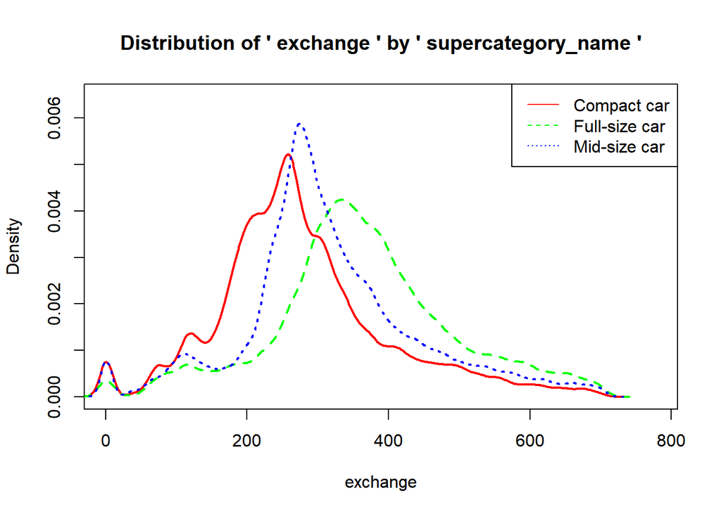

```r
moonBook::densityplot(exchange~supercategory_name, data=repair_sqrt)
```

**total**

```r
ad.test(repair_sqrt$total[repair_sqrt$supercategory_name=="Full-size car"])
```

```
##
##  Anderson-Darling normality test
##
## data:  repair_sqrt$total[repair_sqrt$supercategory_name == "Full-size car"]
## A = 90.027, p-value < 2.2e-16
```

```r
ad.test(repair_sqrt$total[repair_sqrt$supercategory_name=="Mid-size car"])
```

```
##
##  Anderson-Darling normality test
##
## data:  repair_sqrt$total[repair_sqrt$supercategory_name == "Mid-size car"]
## A = 745.2, p-value < 2.2e-16
```

```r
ad.test(repair_sqrt$total[repair_sqrt$supercategory_name=="Compact car"])
```

```
##
##  Anderson-Darling normality test
##
## data:  repair_sqrt$total[repair_sqrt$supercategory_name == "Compact car"]
## A = 406.81, p-value < 2.2e-16
```

**coating**

```r
ad.test(repair_sqrt$coating[repair_sqrt$supercategory_name=="Full-size car"])
```

```
##
##  Anderson-Darling normality test
##
## data:  repair_sqrt$coating[repair_sqrt$supercategory_name == "Full-size car"]
## A = 197.99, p-value < 2.2e-16
```

```r
ad.test(repair_sqrt$coating[repair_sqrt$supercategory_name=="Mid-size car"])
```

```
##
##  Anderson-Darling normality test
##
## data:  repair_sqrt$coating[repair_sqrt$supercategory_name == "Mid-size car"]
## A = 297.11, p-value < 2.2e-16
```

```r
ad.test(repair_sqrt$coating[repair_sqrt$supercategory_name=="Compact car"])
```

```
##
##  Anderson-Darling normality test
##
## data:  repair_sqrt$coating[repair_sqrt$supercategory_name == "Compact car"]
## A = 739.2, p-value < 2.2e-16
```

**sheet_metal**

```r
ad.test(repair_sqrt$sheet_metal[repair_sqrt$supercategory_name=="Full-size car"])
```

```
##
##  Anderson-Darling normality test
##
## data:  repair_sqrt$sheet_metal[repair_sqrt$supercategory_name == "Full-size car"]
## A = 760.07, p-value < 2.2e-16
```

```r
ad.test(repair_sqrt$sheet_metal[repair_sqrt$supercategory_name=="Mid-size car"])
```

```
##
##  Anderson-Darling normality test
##
## data:  repair_sqrt$sheet_metal[repair_sqrt$supercategory_name == "Mid-size car"]
## A = 2946.1, p-value < 2.2e-16
```

```r
ad.test(repair_sqrt$sheet_metal[repair_sqrt$supercategory_name=="Compact car"])
```

```
##
##  Anderson-Darling normality test
##
## data:  repair_sqrt$sheet_metal[repair_sqrt$supercategory_name == "Compact car"]
## A = 1574, p-value < 2.2e-16
```

**exchange**

```r
ad.test(repair_sqrt$exchange[repair_sqrt$supercategory_name=="Full-size car"])
```

```
##
##  Anderson-Darling normality test
##
## data:  repair_sqrt$exchange[repair_sqrt$supercategory_name == "Full-size car"]
## A = 234.02, p-value < 2.2e-16
```

```r
ad.test(repair_sqrt$exchange[repair_sqrt$supercategory_name=="Mid-size car"])
```

```
##
##  Anderson-Darling normality test
##
## data:  repair_sqrt$exchange[repair_sqrt$supercategory_name == "Mid-size car"]
## A = 1602, p-value < 2.2e-16
```

```r
ad.test(repair_sqrt$exchange[repair_sqrt$supercategory_name=="Compact car"])
```

```
##
##  Anderson-Darling normality test
##
## data:  repair_sqrt$exchange[repair_sqrt$supercategory_name == "Compact car"]
## A = 821.55, p-value < 2.2e-16
```

=> 정규분포를 이루지 않으므로 **kruskal검정**으로 진행  
=> 하지만 표본수가 충분하므로 **중심극한정리**에 의해 정규분포를 이룬다고 가정한 상태에서도 진행

#### (2) 등분산 확인

```r
bartlett.test(total~supercategory_name, data=repair_sqrt)
```

```
##
##  Bartlett test of homogeneity of variances
##
## data:  total by supercategory_name
## Bartlett's K-squared = 436.9, df = 2, p-value < 2.2e-16
```

```r
bartlett.test(coating~supercategory_name, data=repair_sqrt)
```

```
##
##  Bartlett test of homogeneity of variances
##
## data:  coating by supercategory_name
## Bartlett's K-squared = 1121.1, df = 2, p-value < 2.2e-16
```

```r
bartlett.test(sheet_metal~supercategory_name, data=repair_sqrt)
```

```
##
##  Bartlett test of homogeneity of variances
##
## data:  sheet_metal by supercategory_name
## Bartlett's K-squared = 368.97, df = 2, p-value < 2.2e-16
```

```r
bartlett.test(exchange~supercategory_name, data=repair_sqrt)
```

```
##
##  Bartlett test of homogeneity of variances
##
## data:  exchange by supercategory_name
## Bartlett's K-squared = 193.61, df = 2, p-value < 2.2e-16
```

=> 등분산을 이루지 않는다.

#### (3) One Way ANOVA

**정규분포라 가정**

```r
oneway.test(total~supercategory_name, data=repair_sqrt, var.equal = F)
```

```
##
##  One-way analysis of means (not assuming equal variances)
##
## data:  total and supercategory_name
## F = 8781.9, num df = 2, denom df = 101583, p-value < 2.2e-16
```

```r
oneway.test(coating~supercategory_name, data=repair_sqrt, var.equal = F)
```

```
##
##  One-way analysis of means (not assuming equal variances)
##
## data:  coating and supercategory_name
## F = 8249, num df = 2, denom df = 101984, p-value < 2.2e-16
```

```r
oneway.test(sheet_metal~supercategory_name, data=repair_sqrt, var.equal = F)
```

```
##
##  One-way analysis of means (not assuming equal variances)
##
## data:  sheet_metal and supercategory_name
## F = 1010.7, num df = 2, denom df = 97895, p-value < 2.2e-16
```

```r
oneway.test(exchange~supercategory_name, data=repair_sqrt, var.equal = F)
```

```
##
##  One-way analysis of means (not assuming equal variances)
##
## data:  exchange and supercategory_name
## F = 5567.7, num df = 2, denom df = 98117, p-value < 2.2e-16
```

**정규분포가 아니면**

```r
kruskal.test(total~supercategory_name, data=repair_sqrt)
```

```
##
##  Kruskal-Wallis rank sum test
##
## data:  total by supercategory_name
## Kruskal-Wallis chi-squared = 16533, df = 2, p-value < 2.2e-16
```

```r
kruskal.test(coating~supercategory_name, data=repair_sqrt)
```

```
##
##  Kruskal-Wallis rank sum test
##
## data:  coating by supercategory_name
## Kruskal-Wallis chi-squared = 15665, df = 2, p-value < 2.2e-16
```

```r
kruskal.test(sheet_metal~supercategory_name, data=repair_sqrt)
```

```
##
##  Kruskal-Wallis rank sum test
##
## data:  sheet_metal by supercategory_name
## Kruskal-Wallis chi-squared = 2221, df = 2, p-value < 2.2e-16
```

```r
kruskal.test(exchange~supercategory_name, data=repair_sqrt)
```

```
##
##  Kruskal-Wallis rank sum test
##
## data:  exchange by supercategory_name
## Kruskal-Wallis chi-squared = 15238, df = 2, p-value < 2.2e-16
```

#### (4) 사후 검정

**정규분포라 가정**

```r
# result <- mctp(total~supercategory_name, data=repair_sqrt)
# summary(result)
# result <- mctp(coating~supercategory_name, data=repair_sqrt)
# summary(result)
# result <- mctp(sheet_metal~supercategory_name, data=repair_sqrt)
# summary(result)
# result <- mctp(exchange~supercategory_name, data=repair_sqrt)
# summary(result)
```

**정규분포가 아니면**

```r
kruskalmc(repair_sqrt$total, repair_sqrt$supercategory_name)
```

```
## Multiple comparison test after Kruskal-Wallis
## alpha: 0.05
## Comparisons
##                             obs.dif critical.dif stat.signif
## Compact car-Full-size car  51753.01     964.7072        TRUE
## Compact car-Mid-size car   18514.73     746.7818        TRUE
## Full-size car-Mid-size car 33238.28     873.0124        TRUE
```

```r
kruskalmc(repair_sqrt$coating, repair_sqrt$supercategory_name)
```

```
## Multiple comparison test after Kruskal-Wallis
## alpha: 0.05
## Comparisons
##                             obs.dif critical.dif stat.signif
## Compact car-Full-size car  50199.45     964.7072        TRUE
## Compact car-Mid-size car   16332.31     746.7818        TRUE
## Full-size car-Mid-size car 33867.14     873.0124        TRUE
```

```r
kruskalmc(repair_sqrt$sheet_metal, repair_sqrt$supercategory_name)
```

```
## Multiple comparison test after Kruskal-Wallis
## alpha: 0.05
## Comparisons
##                              obs.dif critical.dif stat.signif
## Compact car-Full-size car  18259.999     964.7072        TRUE
## Compact car-Mid-size car    4193.652     746.7818        TRUE
## Full-size car-Mid-size car 14066.348     873.0124        TRUE
```

```r
kruskalmc(repair_sqrt$exchange, repair_sqrt$supercategory_name)
```

```
## Multiple comparison test after Kruskal-Wallis
## alpha: 0.05
## Comparisons
##                             obs.dif critical.dif stat.signif
## Compact car-Full-size car  49347.58     964.7072        TRUE
## Compact car-Mid-size car   23442.69     746.7818        TRUE
## Full-size car-Mid-size car 25904.89     873.0124        TRUE
```

### **RESULT**

`차종별 수리비용 차이 존재`

Preview

**total**

| category | difference | P-Value |
| --- | --- | --- |
| `Compact car-Full-size car` | TRUE | 0.0000000 |
| `Compact car-Mid-size car` | TRUE | 0.0000000 |
| `Full-size car-Mid-size car` | TRUE | 0.0000000 |

**coating**

| category | difference | P-Value |
| --- | --- | --- |
| `Compact car-Full-size car` | TRUE | 0.0000000 |
| `Compact car-Mid-size car` | TRUE | 0.0000000 |
| `Full-size car-Mid-size car` | TRUE | 0.0000000 |

**sheet_metal**

| category | difference | P-Value |
| --- | --- | --- |
| `Compact car-Full-size car` | TRUE | 0.0000000 |
| `Compact car-Mid-size car` | TRUE | 0.0000000 |
| `Full-size car-Mid-size car` | TRUE | 0.0000000 |

**exchange**

| category | difference | P-Value |
| --- | --- | --- |
| `Compact car-Full-size car` | TRUE | 0.0000000 |
| `Compact car-Mid-size car` | TRUE | 0.0000000 |
| `Full-size car-Mid-size car` | TRUE | 0.0000000 |

- 각 수리방법마다 차량별 수리비용 차이 존재
- 즉, *귀무가설 기각*
- **차량별 수리비용 차이가 존재**한다고 할 수 있다.

## 2-2. 파손 종류별 수리비용 차이가 존재하는가?

- 귀무가설 : 파손 종류별 수리비용 차이가 존재하지 않는다.
- 대립가설 : 파손 종류별 수리비용 차이가 존재한다.

### 2-2-1. Feature Review

- damage(파손유형) : Breakage(파손), Crushed(찌그러짐), Scratched(스크래치), Separated(이격)
- total(총지불금액) = coating(도장공임) + sheet_metal(판금수리) + exchange(탈착교환)

**파손유형 변수 검토**

```r
table(repair_car$damage)
```

```
##
##  Breakage   Crushed Scratched Separated
##     37703     43738     98741     52532
```

**파손유형별 총 개수와 평균 수리비용 조회**

```r
mean_damage <- repair_car %>% group_by(damage) %>%
                  summarise(mean_total = mean(total), mean_coating = mean(coating),
                            mean_sheet_metal = mean(sheet_metal), mean_exchange = mean(exchange),
                            count = n())
mean_damage
```

```
## # A tibble: 4 × 6
##   damage    mean_total mean_coating mean_sheet_metal mean_exchange count
##   <chr>          <dbl>        <dbl>            <dbl>         <dbl> <int>
## 1 Breakage     433471.      186089.           68217.       179165. 37703
## 2 Crushed      480273.      223298.           89866.       167109. 43738
## 3 Scratched    382465.      186048.           68020.       128397. 98741
## 4 Separated    433478.      196347.           73984.       163147. 52532
```

### 2-2-2. 시각화

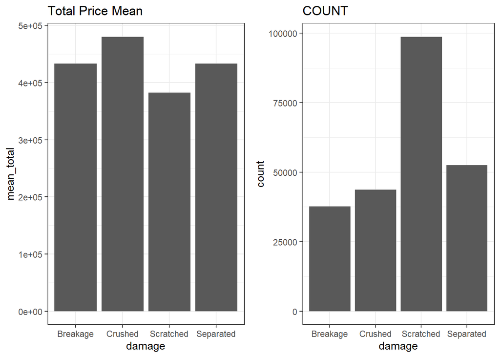

```r
# 파손유형에 따른 총 수리비용 평균과 분포 개수 확인 #
theme_set(theme_bw())
g1 <- ggplot(data = mean_damage, aes(x=damage, y=mean_total)) + geom_col() +
  labs(title="Total Price Mean")
g2 <- ggplot(data = mean_damage, aes(x=damage, y=count)) + geom_col() +
  labs(title="COUNT")
grid.arrange(g1, g2, ncol=2)
```

### 2-2-3. 극단값 조정

- repair_sqrt 이용

### 2-2-4. Statistical Test

#### (1) 정규분포 확인

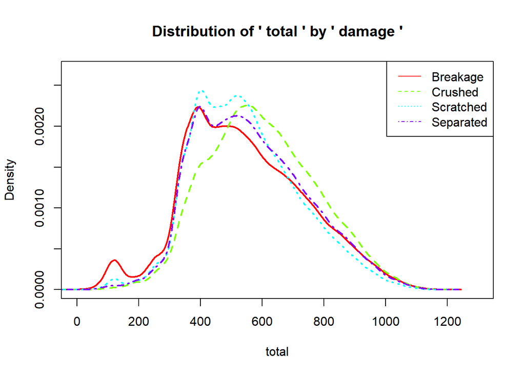

```r
moonBook::densityplot(total~damage, data=repair_sqrt)
```

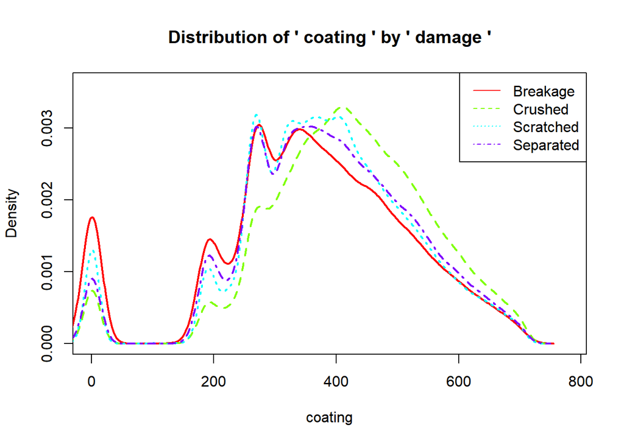

```r
moonBook::densityplot(coating~damage, data=repair_sqrt)
```

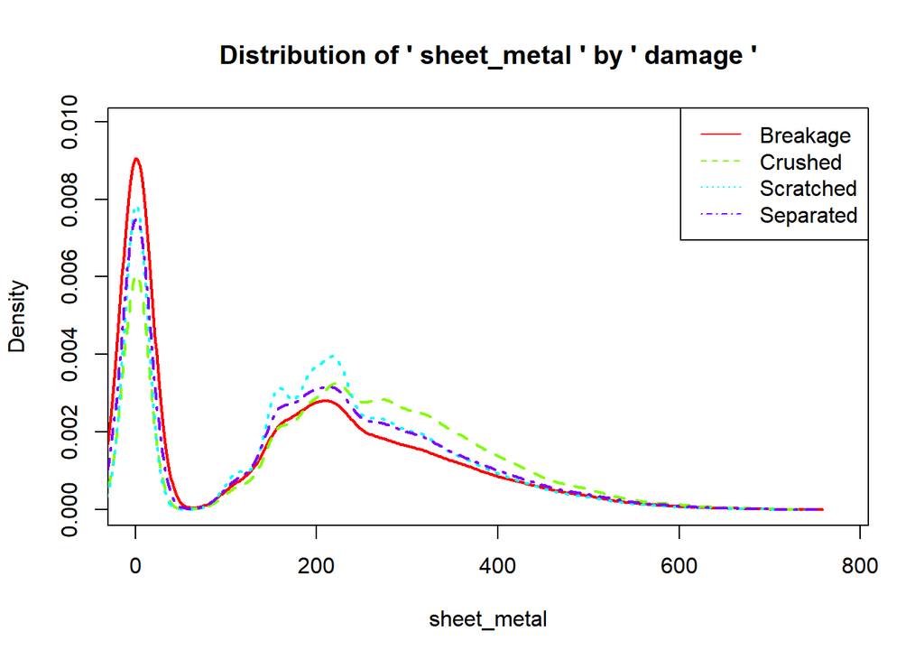

```r
moonBook::densityplot(sheet_metal~damage, data=repair_sqrt)
```

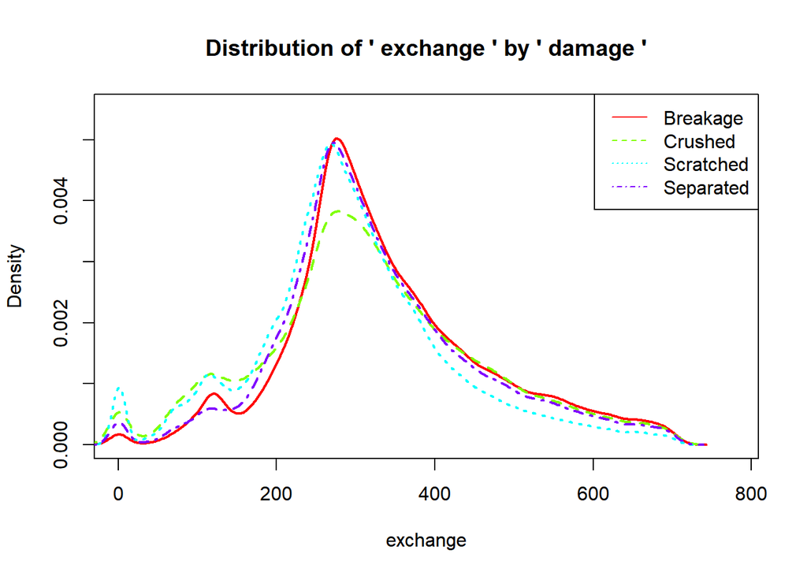

```r
moonBook::densityplot(exchange~damage, data=repair_sqrt)
```

**total**

```r
ad.test(repair_sqrt$total[repair_sqrt$damage=="Scratched"])
```

```
##
##  Anderson-Darling normality test
##
## data:  repair_sqrt$total[repair_sqrt$damage == "Scratched"]
## A = 479.72, p-value < 2.2e-16
```

```r
ad.test(repair_sqrt$total[repair_sqrt$damage=="Crushed"])
```

```
##
##  Anderson-Darling normality test
##
## data:  repair_sqrt$total[repair_sqrt$damage == "Crushed"]
## A = 77.15, p-value < 2.2e-16
```

```r
ad.test(repair_sqrt$total[repair_sqrt$damage=="Separated"])
```

```
##
##  Anderson-Darling normality test
##
## data:  repair_sqrt$total[repair_sqrt$damage == "Separated"]
## A = 268.76, p-value < 2.2e-16
```

```r
ad.test(repair_sqrt$total[repair_sqrt$damage=="Breakage"])
```

```
##
##  Anderson-Darling normality test
##
## data:  repair_sqrt$total[repair_sqrt$damage == "Breakage"]
## A = 142.62, p-value < 2.2e-16
```

**coating**

```r
ad.test(repair_sqrt$coating[repair_sqrt$damage=="Scratched"])
```

```
##
##  Anderson-Darling normality test
##
## data:  repair_sqrt$coating[repair_sqrt$damage == "Scratched"]
## A = 427.01, p-value < 2.2e-16
```

```r
ad.test(repair_sqrt$coating[repair_sqrt$damage=="Crushed"])
```

```
##
##  Anderson-Darling normality test
##
## data:  repair_sqrt$coating[repair_sqrt$damage == "Crushed"]
## A = 112.33, p-value < 2.2e-16
```

```r
ad.test(repair_sqrt$coating[repair_sqrt$damage=="Separated"])
```

```
##
##  Anderson-Darling normality test
##
## data:  repair_sqrt$coating[repair_sqrt$damage == "Separated"]
## A = 141.95, p-value < 2.2e-16
```

```r
ad.test(repair_sqrt$coating[repair_sqrt$damage=="Breakage"])
```

```
##
##  Anderson-Darling normality test
##
## data:  repair_sqrt$coating[repair_sqrt$damage == "Breakage"]
## A = 246.05, p-value < 2.2e-16
```

**sheet_metal**

```r
ad.test(repair_sqrt$sheet_metal[repair_sqrt$damage=="Scratched"])
```

```
##
##  Anderson-Darling normality test
##
## data:  repair_sqrt$sheet_metal[repair_sqrt$damage == "Scratched"]
## A = 1989.4, p-value < 2.2e-16
```

```r
ad.test(repair_sqrt$sheet_metal[repair_sqrt$damage=="Crushed"])
```

```
##
##  Anderson-Darling normality test
##
## data:  repair_sqrt$sheet_metal[repair_sqrt$damage == "Crushed"]
## A = 695.24, p-value < 2.2e-16
```

```r
ad.test(repair_sqrt$sheet_metal[repair_sqrt$damage=="Separated"])
```

```
##
##  Anderson-Darling normality test
##
## data:  repair_sqrt$sheet_metal[repair_sqrt$damage == "Separated"]
## A = 1255.5, p-value < 2.2e-16
```

```r
ad.test(repair_sqrt$sheet_metal[repair_sqrt$damage=="Breakage"])
```

```
##
##  Anderson-Darling normality test
##
## data:  repair_sqrt$sheet_metal[repair_sqrt$damage == "Breakage"]
## A = 1545.5, p-value < 2.2e-16
```

**exchange**

```r
ad.test(repair_sqrt$exchange[repair_sqrt$damage=="Scratched"])
```

```
##
##  Anderson-Darling normality test
##
## data:  repair_sqrt$exchange[repair_sqrt$damage == "Scratched"]
## A = 734.64, p-value < 2.2e-16
```

```r
ad.test(repair_sqrt$exchange[repair_sqrt$damage=="Crushed"])
```

```
##
##  Anderson-Darling normality test
##
## data:  repair_sqrt$exchange[repair_sqrt$damage == "Crushed"]
## A = 162.69, p-value < 2.2e-16
```

```r
ad.test(repair_sqrt$exchange[repair_sqrt$damage=="Separated"])
```

```
##
##  Anderson-Darling normality test
##
## data:  repair_sqrt$exchange[repair_sqrt$damage == "Separated"]
## A = 581.34, p-value < 2.2e-16
```

```r
ad.test(repair_sqrt$exchange[repair_sqrt$damage=="Breakage"])
```

```
##
##  Anderson-Darling normality test
##
## data:  repair_sqrt$exchange[repair_sqrt$damage == "Breakage"]
## A = 448.84, p-value < 2.2e-16
```

=> 정규분포를 이루지 않으므로 **kruskal검정**으로 진행  
=> 하지만 표본수가 충분하므로 **중심극한정리**에 의해 정규분포를 이룬다고 가정한 상태에서도 진행

#### (2) 등분산 확인

```r
bartlett.test(total~damage, data=repair_sqrt)
```

```
##
##  Bartlett test of homogeneity of variances
##
## data:  total by damage
## Bartlett's K-squared = 927.14, df = 3, p-value < 2.2e-16
```

```r
bartlett.test(coating~damage, data=repair_sqrt)
```

```
##
##  Bartlett test of homogeneity of variances
##
## data:  coating by damage
## Bartlett's K-squared = 1082.5, df = 3, p-value < 2.2e-16
```

```r
bartlett.test(sheet_metal~damage, data=repair_sqrt)
```

```
##
##  Bartlett test of homogeneity of variances
##
## data:  sheet_metal by damage
## Bartlett's K-squared = 510.03, df = 3, p-value < 2.2e-16
```

```r
bartlett.test(exchange~damage, data=repair_sqrt)
```

```
##
##  Bartlett test of homogeneity of variances
##
## data:  exchange by damage
## Bartlett's K-squared = 908.97, df = 3, p-value < 2.2e-16
```

=> 등분산을 이루지 않는다.

#### (3) One Way ANOVA

**정규분포라 가정**

```r
oneway.test(total~damage, data=repair_sqrt, var.equal = F)
```

```
##
##  One-way analysis of means (not assuming equal variances)
##
## data:  total and damage
## F = 928.47, num df = 3, denom df = 92623, p-value < 2.2e-16
```

```r
oneway.test(coating~damage, data=repair_sqrt, var.equal = F)
```

```
##
##  One-way analysis of means (not assuming equal variances)
##
## data:  coating and damage
## F = 1064.9, num df = 3, denom df = 93494, p-value < 2.2e-16
```

```r
oneway.test(sheet_metal~damage, data=repair_sqrt, var.equal = F)
```

```
##
##  One-way analysis of means (not assuming equal variances)
##
## data:  sheet_metal and damage
## F = 1057.3, num df = 3, denom df = 92828, p-value < 2.2e-16
```

```r
oneway.test(exchange~damage, data=repair_sqrt, var.equal = F)
```

```
##
##  One-way analysis of means (not assuming equal variances)
##
## data:  exchange and damage
## F = 1243.6, num df = 3, denom df = 93295, p-value < 2.2e-16
```

**정규분포가 아니면**

```r
kruskal.test(total~damage, data=repair_sqrt)
```

```
##
##  Kruskal-Wallis rank sum test
##
## data:  total by damage
## Kruskal-Wallis chi-squared = 2779.4, df = 3, p-value < 2.2e-16
```

```r
kruskal.test(coating~damage, data=repair_sqrt)
```

```
##
##  Kruskal-Wallis rank sum test
##
## data:  coating by damage
## Kruskal-Wallis chi-squared = 3252, df = 3, p-value < 2.2e-16
```

```r
kruskal.test(sheet_metal~damage, data=repair_sqrt)
```

```
##
##  Kruskal-Wallis rank sum test
##
## data:  sheet_metal by damage
## Kruskal-Wallis chi-squared = 3510.6, df = 3, p-value < 2.2e-16
```

```r
kruskal.test(exchange~damage, data=repair_sqrt)
```

```
##
##  Kruskal-Wallis rank sum test
##
## data:  exchange by damage
## Kruskal-Wallis chi-squared = 3387.7, df = 3, p-value < 2.2e-16
```

#### (4) 사후 검정

**정규분포라 가정**

```r
# result <- mctp(total~damage, data=repair_sqrt)
# summary(result)
# result <- mctp(coating~damage, data=repair_sqrt)
# summary(result)
# result <- mctp(sheet_metal~damage, data=repair_sqrt)
# summary(result)
# result <- mctp(exchange~damage, data=repair_sqrt)
# summary(result)
```

**정규분포가 아니면**

```r
kruskalmc(repair_sqrt$total, repair_sqrt$damage)
```

```
## Multiple comparison test after Kruskal-Wallis
## alpha: 0.05
## Comparisons
##                         obs.dif critical.dif stat.signif
## Breakage-Crushed    18842.14844    1212.8096        TRUE
## Breakage-Scratched     12.66628    1039.0298       FALSE
## Breakage-Separated   5779.46799    1161.4871        TRUE
## Crushed-Scratched   18854.81472     986.8585        TRUE
## Crushed-Separated   13062.68045    1115.0601        TRUE
## Scratched-Separated  5792.13427     923.0573        TRUE
```

```r
kruskalmc(repair_sqrt$coating, repair_sqrt$damage)
```

```
## Multiple comparison test after Kruskal-Wallis
## alpha: 0.05
## Comparisons
##                       obs.dif critical.dif stat.signif
## Breakage-Crushed    24862.581    1212.8096        TRUE
## Breakage-Scratched   7895.190    1039.0298        TRUE
## Breakage-Separated   9079.198    1161.4871        TRUE
## Crushed-Scratched   16967.391     986.8585        TRUE
## Crushed-Separated   15783.383    1115.0601        TRUE
## Scratched-Separated  1184.008     923.0573        TRUE
```

```r
kruskalmc(repair_sqrt$sheet_metal, repair_sqrt$damage)
```

```
## Multiple comparison test after Kruskal-Wallis
## alpha: 0.05
## Comparisons
##                       obs.dif critical.dif stat.signif
## Breakage-Crushed    26564.344    1212.8096        TRUE
## Breakage-Scratched  12309.616    1039.0298        TRUE
## Breakage-Separated  10797.080    1161.4871        TRUE
## Crushed-Scratched   14254.729     986.8585        TRUE
## Crushed-Separated   15767.264    1115.0601        TRUE
## Scratched-Separated  1512.536     923.0573        TRUE
```

```r
kruskalmc(repair_sqrt$exchange, repair_sqrt$damage)
```

```
## Multiple comparison test after Kruskal-Wallis
## alpha: 0.05
## Comparisons
##                       obs.dif critical.dif stat.signif
## Breakage-Crushed     8205.405    1212.8096        TRUE
## Breakage-Scratched  19994.199    1039.0298        TRUE
## Breakage-Separated   5929.330    1161.4871        TRUE
## Crushed-Scratched   11788.794     986.8585        TRUE
## Crushed-Separated    2276.076    1115.0601        TRUE
## Scratched-Separated 14064.869     923.0573        TRUE
```

### **RESULT**

`파손 유형별 수리비용 차이 존재`

Preview

**total**

| damage | difference | P-Value |
| --- | --- | --- |
| `Breakage-Crushed` | TRUE | 0.0000000 |
| `Breakage-Scratched` | **FALSE** | 0.9888212 |
| `Breakage-Separated` | TRUE | 0.0000000 |
| `Crushed-Scratched` | TRUE | 0.0000000 |
| `Crushed-Separated` | TRUE | 0.0000000 |
| `Scratched-Separated` | TRUE | 0.0000000 |

**coating**

| damage | difference | P-Value |
| --- | --- | --- |
| `Breakage-Crushed` | TRUE | 0.0000000 |
| `Breakage-Scratched` | TRUE | 0.0000000 |
| `Breakage-Separated` | TRUE | 0.0000000 |
| `Crushed-Scratched` | TRUE | 0.0000000 |
| `Crushed-Separated` | TRUE | 0.0000000 |
| `Scratched-Separated` | TRUE | 0.002928318 |

**sheet_metal**

| damage | difference | P-Value |
| --- | --- | --- |
| `Breakage-Crushed` | TRUE | 0.0000000 |
| `Breakage-Scratched` | TRUE | 0.0000000 |
| `Breakage-Separated` | TRUE | 0.0000000 |
| `Crushed-Scratched` | TRUE | 0.0000000 |
| `Crushed-Separated` | TRUE | 0.0000000 |
| `Scratched-Separated` | TRUE | 6.652105e-05 |

**exchange**

| damage | difference | P-Value |
| --- | --- | --- |
| `Breakage-Crushed` | TRUE | 0.0000000 |
| `Breakage-Scratched` | TRUE | 0.0000000 |
| `Breakage-Separated` | TRUE | 0.0000000 |
| `Crushed-Scratched` | TRUE | 0.0000000 |
| `Crushed-Separated` | TRUE | 1.031642e-05 |
| `Scratched-Separated` | TRUE | 0.0000000 |

- total에서 *Breakage-Scratched* 제외하고 전부 차이 존재
- 각 수리방법마다 파손유형별 수리비용 차이 존재
- 즉, *귀무가설 기각*
- **파손 유형별 수리비용 차이가 존재**한다고 할 수 있다.

## 2-3. 차량 색상별 수리비용 차이가 존재하는가?

- 귀무가설 : 차량 색상별 수리비용 차이가 존재하지 않는다.
- 대립가설 : 차량 색상별 수리비용 차이가 존재한다.

### 2-3-1. Feature Review

- color(차량색상) : White(흰색), Gray tone(회색), Black(검은색), Blue tone(파란색), Red tone(빨간색), Others(기타)
- total(총지불금액) = coating(도장공임) + sheet_metal(판금수리) + exchange(탈착교환)

**차량 색상별 변수 검토**

```r
table(repair_car_cy$color)
```

```
##
##     Black Blue tone Gray tone    Others  Red tone     White
##     18787      3363      8902      3964      1290     70903
```

**차량 색상별 총 개수와 평균 수리비용 조회**

```r
mean_color <- repair_car_cy %>% group_by(color) %>%
                  summarise(mean_total = mean(total), mean_coating = mean(coating),
                            mean_sheet_metal = mean(sheet_metal),
                            mean_exchange =mean(exchange),
                            count = n())
mean_color
```

```
## # A tibble: 6 × 6
##   color     mean_total mean_coating mean_sheet_metal mean_exchange count
##   <chr>          <dbl>        <dbl>            <dbl>         <dbl> <int>
## 1 Black        524077.      244099.           91513.       188465. 18787
## 2 Blue tone    519793.      236373.           90145.       193276.  3363
## 3 Gray tone    532483.      248172.           93909.       190402.  8902
## 4 Others       485272.      222347.           87915.       175010.  3964
## 5 Red tone     496207.      238506.           91008.       166693.  1290
## 6 White        318985.      158472.           56734.       103779. 70903
```

### 2-3-2. 시각화

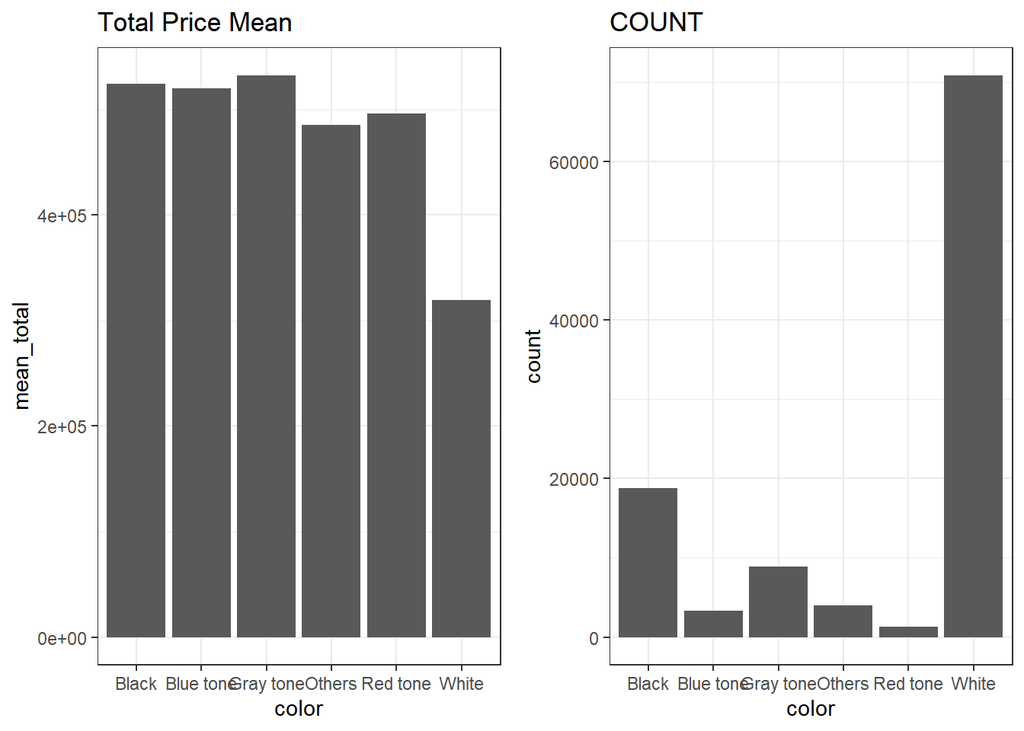

```r
# 차량 색상에 따른 총 수리비용 평균과 분포 개수 확인 #
theme_set(theme_bw())
g1 <- ggplot(data = mean_color, aes(x=color, y=mean_total)) + geom_col() +
  labs(title="Total Price Mean")
g2 <- ggplot(data = mean_color, aes(x=color, y=count)) + geom_col() +
  labs(title="COUNT")
grid.arrange(g1, g2, ncol=2)
```

### 2-3-3. 극단값 조정

```r
# 극단값 제거
repair_cy_sqrt <- subset(repair_car_cy, coating <= 5e+05 & sheet_metal <= 5e+05 & exchange <= 5e+05)

# 정규화 해주기
repair_cy_sqrt <- transform(repair_cy_sqrt, coating = sqrt(coating + 1))
repair_cy_sqrt <- transform(repair_cy_sqrt, sheet_metal = sqrt(sheet_metal + 1))
repair_cy_sqrt <- transform(repair_cy_sqrt, exchange = sqrt(exchange + 1))
repair_cy_sqrt <- transform(repair_cy_sqrt, total = sqrt(total + 1))

repair_cy_sqrt %>% head(7)
```

```
##   category_id  coating sheet_metal exchange     total year     color
## 1  as-0000025 698.9285    418.3312 381.7735  899.5838 2016     White
## 2  as-0000027 704.6283    512.3485 517.4466 1013.2872 2015 Gray tone
## 3  as-0000029 409.2689    273.8631 212.1344  536.1912 2017     White
## 4  as-0000034 382.4278    223.6090 170.2968  474.6062 2018     Black
## 5  as-0000037 362.2858    193.6517 224.1673  467.9754 2017     Black
## 6  as-0000040 531.9022    330.6826 191.5489  654.9504 2016     White
## 7  as-0000041 484.8144    190.9214 241.0000  574.0862 2017     White
```

```r
table(repair_cy_sqrt$color)
```

```
##
##     Black Blue tone Gray tone    Others  Red tone     White
##     16886      3014      8046      3649      1171     68654
```

### 2-3-4. Statistical Test

#### (1) 정규분포 확인

- Blue tone, Red tone, Others는 5000개 이하이므로 shapiro test, 나머지 Anderson-Darling test 진행

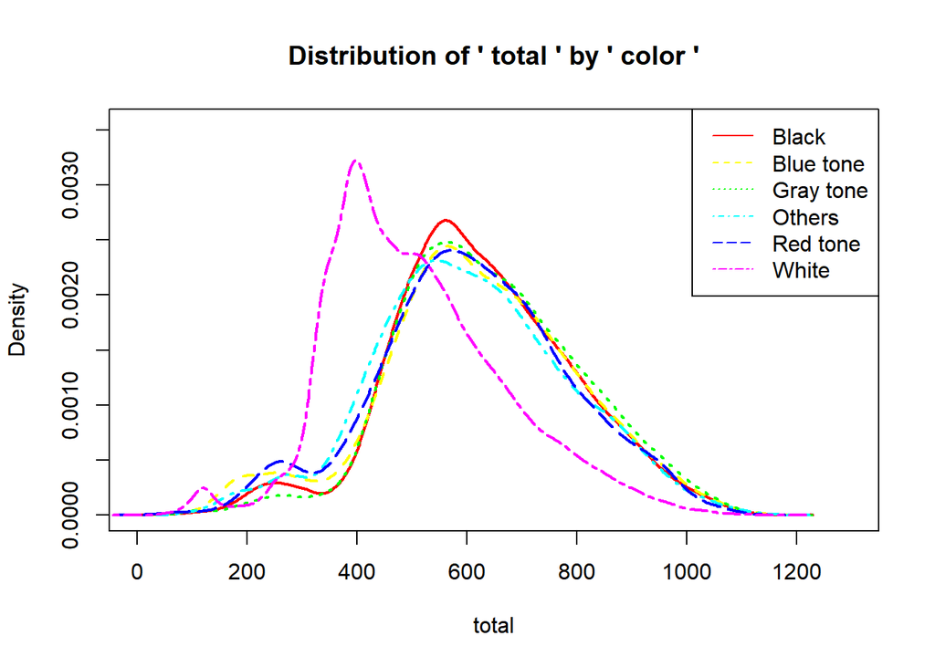

```r
moonBook::densityplot(total~color, data=repair_cy_sqrt)
```

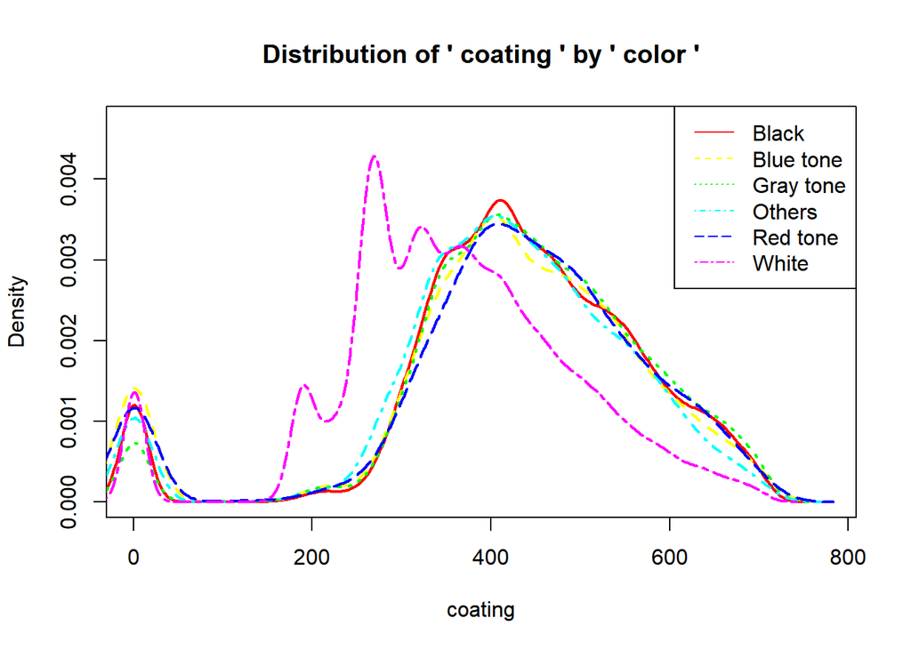

```r
moonBook::densityplot(coating~color, data=repair_cy_sqrt)
```

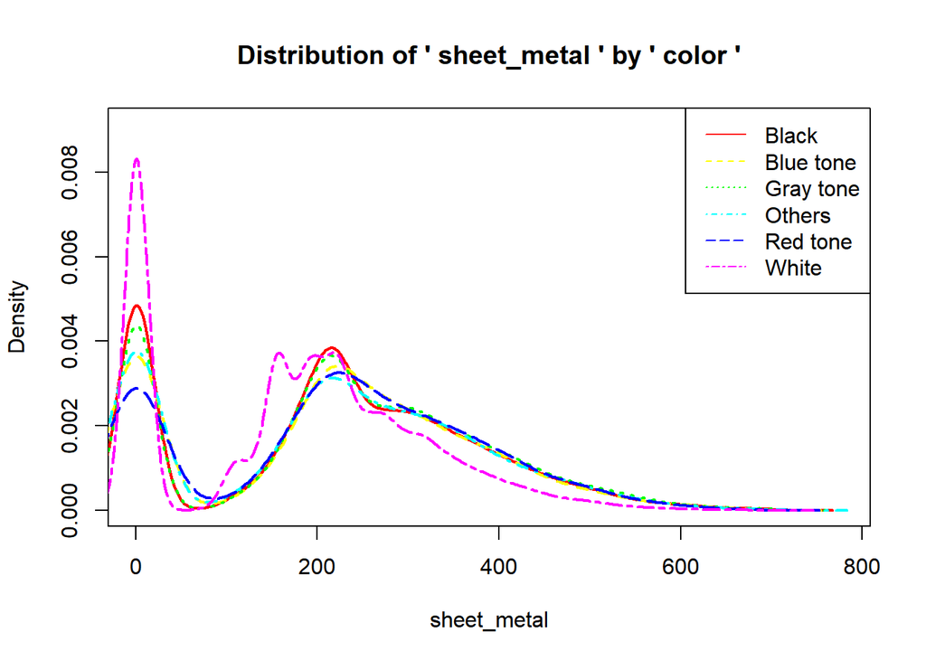

```r
moonBook::densityplot(sheet_metal~color, data=repair_cy_sqrt)
```

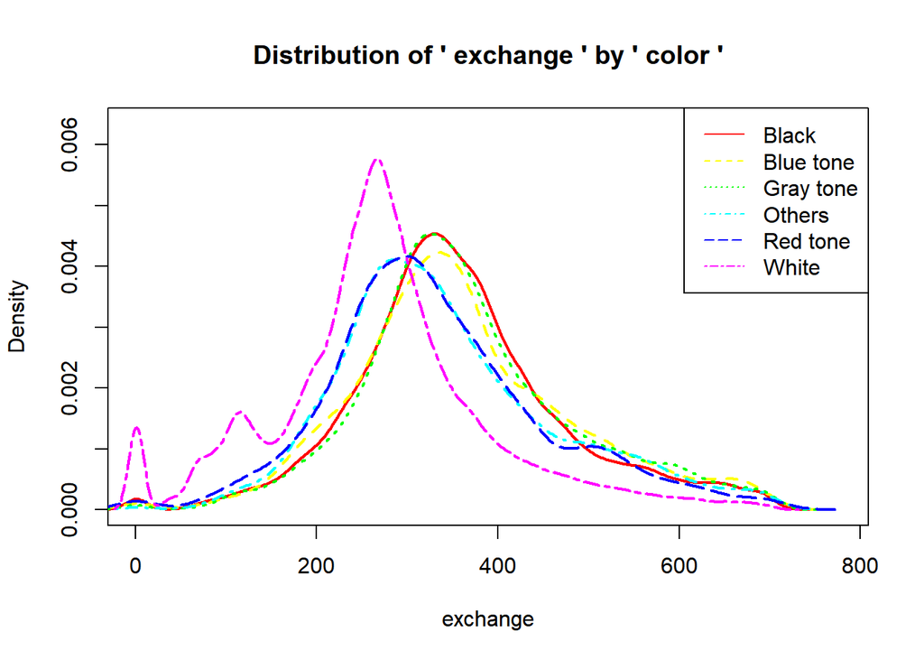

```r
moonBook::densityplot(exchange~color, data=repair_cy_sqrt)
```

**total**

```r
ad.test(repair_cy_sqrt$total[repair_cy_sqrt$color=="White"])
```

```
##
##  Anderson-Darling normality test
##
## data:  repair_cy_sqrt$total[repair_cy_sqrt$color == "White"]
## A = 613.66, p-value < 2.2e-16
```

```r
ad.test(repair_cy_sqrt$total[repair_cy_sqrt$color=="Gray tone"])
```

```
##
##  Anderson-Darling normality test
##
## data:  repair_cy_sqrt$total[repair_cy_sqrt$color == "Gray tone"]
## A = 19.493, p-value < 2.2e-16
```

```r
ad.test(repair_cy_sqrt$total[repair_cy_sqrt$color=="Black"])
```

```
##
##  Anderson-Darling normality test
##
## data:  repair_cy_sqrt$total[repair_cy_sqrt$color == "Black"]
## A = 38.015, p-value < 2.2e-16
```

```r
shapiro.test(repair_cy_sqrt$total[repair_cy_sqrt$color=="Blue tone"])
```

```
##
##  Shapiro-Wilk normality test
##
## data:  repair_cy_sqrt$total[repair_cy_sqrt$color == "Blue tone"]
## W = 0.99159, p-value = 2.677e-12
```

```r
shapiro.test(repair_cy_sqrt$total[repair_cy_sqrt$color=="Red tone"])
```

```
##
##  Shapiro-Wilk normality test
##
## data:  repair_cy_sqrt$total[repair_cy_sqrt$color == "Red tone"]
## W = 0.99491, p-value = 0.0005461
```

```r
shapiro.test(repair_cy_sqrt$total[repair_cy_sqrt$color=="Others"])
```

```
##
##  Shapiro-Wilk normality test
##
## data:  repair_cy_sqrt$total[repair_cy_sqrt$color == "Others"]
## W = 0.99633, p-value = 8.388e-08
```

**coating**

```r
ad.test(repair_cy_sqrt$coating[repair_cy_sqrt$color=="White"])
```

```
##
##  Anderson-Darling normality test
##
## data:  repair_cy_sqrt$coating[repair_cy_sqrt$color == "White"]
## A = 417.14, p-value < 2.2e-16
```

```r
ad.test(repair_cy_sqrt$coating[repair_cy_sqrt$color=="Gray tone"])
```

```
##
##  Anderson-Darling normality test
##
## data:  repair_cy_sqrt$coating[repair_cy_sqrt$color == "Gray tone"]
## A = 75.753, p-value < 2.2e-16
```

```r
ad.test(repair_cy_sqrt$coating[repair_cy_sqrt$color=="Black"])
```

```
##
##  Anderson-Darling normality test
##
## data:  repair_cy_sqrt$coating[repair_cy_sqrt$color == "Black"]
## A = 264.04, p-value < 2.2e-16
```

```r
shapiro.test(repair_cy_sqrt$coating[repair_cy_sqrt$color=="Blue tone"])
```

```
##
##  Shapiro-Wilk normality test
##
## data:  repair_cy_sqrt$coating[repair_cy_sqrt$color == "Blue tone"]
## W = 0.89475, p-value < 2.2e-16
```

```r
shapiro.test(repair_cy_sqrt$coating[repair_cy_sqrt$color=="Red tone"])
```

```
##
##  Shapiro-Wilk normality test
##
## data:  repair_cy_sqrt$coating[repair_cy_sqrt$color == "Red tone"]
## W = 0.89221, p-value < 2.2e-16
```

```r
shapiro.test(repair_cy_sqrt$coating[repair_cy_sqrt$color=="Others"])
```

```
##
##  Shapiro-Wilk normality test
##
## data:  repair_cy_sqrt$coating[repair_cy_sqrt$color == "Others"]
## W = 0.9153, p-value < 2.2e-16
```

**sheet_metal**

```r
ad.test(repair_cy_sqrt$sheet_metal[repair_cy_sqrt$color=="White"])
```

```
##
##  Anderson-Darling normality test
##
## data:  repair_cy_sqrt$sheet_metal[repair_cy_sqrt$color == "White"]
## A = 1660.6, p-value < 2.2e-16
```

```r
ad.test(repair_cy_sqrt$sheet_metal[repair_cy_sqrt$color=="Gray tone"])
```

```
##
##  Anderson-Darling normality test
##
## data:  repair_cy_sqrt$sheet_metal[repair_cy_sqrt$color == "Gray tone"]
## A = 153.41, p-value < 2.2e-16
```

```r
ad.test(repair_cy_sqrt$sheet_metal[repair_cy_sqrt$color=="Black"])
```

```
##
##  Anderson-Darling normality test
##
## data:  repair_cy_sqrt$sheet_metal[repair_cy_sqrt$color == "Black"]
## A = 362.22, p-value < 2.2e-16
```

```r
shapiro.test(repair_cy_sqrt$sheet_metal[repair_cy_sqrt$color=="Blue tone"])
```

```
##
##  Shapiro-Wilk normality test
##
## data:  repair_cy_sqrt$sheet_metal[repair_cy_sqrt$color == "Blue tone"]
## W = 0.92609, p-value < 2.2e-16
```

```r
shapiro.test(repair_cy_sqrt$sheet_metal[repair_cy_sqrt$color=="Red tone"])
```

```
##
##  Shapiro-Wilk normality test
##
## data:  repair_cy_sqrt$sheet_metal[repair_cy_sqrt$color == "Red tone"]
## W = 0.9335, p-value < 2.2e-16
```

```r
shapiro.test(repair_cy_sqrt$sheet_metal[repair_cy_sqrt$color=="Others"])
```

```
##
##  Shapiro-Wilk normality test
##
## data:  repair_cy_sqrt$sheet_metal[repair_cy_sqrt$color == "Others"]
## W = 0.92882, p-value < 2.2e-16
```

**exchange**

```r
ad.test(repair_cy_sqrt$exchange[repair_cy_sqrt$color=="White"])
```

```
##
##  Anderson-Darling normality test
##
## data:  repair_cy_sqrt$exchange[repair_cy_sqrt$color == "White"]
## A = 693.19, p-value < 2.2e-16
```

```r
ad.test(repair_cy_sqrt$exchange[repair_cy_sqrt$color=="Gray tone"])
```

```
##
##  Anderson-Darling normality test
##
## data:  repair_cy_sqrt$exchange[repair_cy_sqrt$color == "Gray tone"]
## A = 79.824, p-value < 2.2e-16
```

```r
ad.test(repair_cy_sqrt$exchange[repair_cy_sqrt$color=="Black"])
```

```
##
##  Anderson-Darling normality test
##
## data:  repair_cy_sqrt$exchange[repair_cy_sqrt$color == "Black"]
## A = 134.7, p-value < 2.2e-16
```

```r
shapiro.test(repair_cy_sqrt$exchange[repair_cy_sqrt$color=="Blue tone"])
```

```
##
##  Shapiro-Wilk normality test
##
## data:  repair_cy_sqrt$exchange[repair_cy_sqrt$color == "Blue tone"]
## W = 0.97848, p-value < 2.2e-16
```

```r
shapiro.test(repair_cy_sqrt$exchange[repair_cy_sqrt$color=="Red tone"])
```

```
##
##  Shapiro-Wilk normality test
##
## data:  repair_cy_sqrt$exchange[repair_cy_sqrt$color == "Red tone"]
## W = 0.97498, p-value = 2.34e-13
```

```r
shapiro.test(repair_cy_sqrt$exchange[repair_cy_sqrt$color=="Others"])
```

```
##
##  Shapiro-Wilk normality test
##
## data:  repair_cy_sqrt$exchange[repair_cy_sqrt$color == "Others"]
## W = 0.96385, p-value < 2.2e-16
```

=> 정규분포를 이루지 않으므로 **kruskal검정**으로 진행  
=> 하지만 표본수가 충분하므로 **중심극한정리**에 의해 정규분포를 이룬다고 가정한 상태에서도 진행

#### (2) 등분산 확인

```r
bartlett.test(total~color, data=repair_cy_sqrt)
```

```
##
##  Bartlett test of homogeneity of variances
##
## data:  total by color
## Bartlett's K-squared = 189.72, df = 5, p-value < 2.2e-16
```

```r
bartlett.test(coating~color, data=repair_cy_sqrt)
```

```
##
##  Bartlett test of homogeneity of variances
##
## data:  coating by color
## Bartlett's K-squared = 297.43, df = 5, p-value < 2.2e-16
```

```r
bartlett.test(sheet_metal~color, data=repair_cy_sqrt)
```

```
##
##  Bartlett test of homogeneity of variances
##
## data:  sheet_metal by color
## Bartlett's K-squared = 781.03, df = 5, p-value < 2.2e-16
```

```r
bartlett.test(exchange~color, data=repair_cy_sqrt)
```

```
##
##  Bartlett test of homogeneity of variances
##
## data:  exchange by color
## Bartlett's K-squared = 30.609, df = 5, p-value = 1.119e-05
```

=> 등분산을 이루지 않는다.

#### (3) One Way ANOVA

**정규분포라 가정**

```r
oneway.test(total~color, data=repair_cy_sqrt, var.equal = F)
```

```
##
##  One-way analysis of means (not assuming equal variances)
##
## data:  total and color
## F = 2329.1, num df = 5.0, denom df = 7476.8, p-value < 2.2e-16
```

```r
oneway.test(coating~color, data=repair_cy_sqrt, var.equal = F)
```

```
##
##  One-way analysis of means (not assuming equal variances)
##
## data:  coating and color
## F = 1332.8, num df = 5, denom df = 7469, p-value < 2.2e-16
```

```r
oneway.test(sheet_metal~color, data=repair_cy_sqrt, var.equal = F)
```

```
##
##  One-way analysis of means (not assuming equal variances)
##
## data:  sheet_metal and color
## F = 378.07, num df = 5.0, denom df = 7454.3, p-value < 2.2e-16
```

```r
oneway.test(exchange~color, data=repair_cy_sqrt, var.equal = F)
```

```
##
##  One-way analysis of means (not assuming equal variances)
##
## data:  exchange and color
## F = 2472.7, num df = 5.0, denom df = 7512.6, p-value < 2.2e-16
```

**정규분포가 아니면**

```r
kruskal.test(total~color, data=repair_cy_sqrt)
```

```
##
##  Kruskal-Wallis rank sum test
##
## data:  total by color
## Kruskal-Wallis chi-squared = 11860, df = 5, p-value < 2.2e-16
```

```r
kruskal.test(coating~color, data=repair_cy_sqrt)
```

```
##
##  Kruskal-Wallis rank sum test
##
## data:  coating by color
## Kruskal-Wallis chi-squared = 9014.2, df = 5, p-value < 2.2e-16
```

```r
kruskal.test(sheet_metal~color, data=repair_cy_sqrt)
```

```
##
##  Kruskal-Wallis rank sum test
##
## data:  sheet_metal by color
## Kruskal-Wallis chi-squared = 2224.3, df = 5, p-value < 2.2e-16
```

```r
kruskal.test(exchange~color, data=repair_cy_sqrt)
```

```
##
##  Kruskal-Wallis rank sum test
##
## data:  exchange by color
## Kruskal-Wallis chi-squared = 12758, df = 5, p-value < 2.2e-16
```

#### (4) 사후 검정

**정규분포라 가정**

```r
# result <- mctp(total~color, data=repair_cy_sqrt)
# summary(result)
# result <- mctp(coating~color, data=repair_cy_sqrt)
# summary(result)
# result <- mctp(sheet_metal~color, data=repair_cy_sqrt)
# summary(result)
# result <- mctp(exchange~color, data=repair_cy_sqrt)
# summary(result)
```

**정규분포가 아니면**

```r
kruskalmc(repair_cy_sqrt$total, repair_cy_sqrt$color)
```

```
## Multiple comparison test after Kruskal-Wallis
## alpha: 0.05
## Comparisons
##                        obs.dif critical.dif stat.signif
## Black-Blue tone      1373.5317    1699.2773       FALSE
## Black-Gray tone      1901.6176    1164.1204        TRUE
## Black-Others         3788.0399    1568.8079        TRUE
## Black-Red tone       2864.6520    2596.8909        TRUE
## Black-White         21491.2627     738.1779        TRUE
## Blue tone-Gray tone  3275.1493    1835.2223        TRUE
## Blue tone-Others     2414.5082    2115.1886        TRUE
## Blue tone-Red tone   1491.1203    2959.1733       FALSE
## Blue tone-White     20117.7310    1599.3033        TRUE
## Gray tone-Others     5689.6574    1715.1255        TRUE
## Gray tone-Red tone   4766.2696    2687.8132        TRUE
## Gray tone-White     23392.8803    1012.6223        TRUE
## Others-Red tone       923.3878    2886.2297       FALSE
## Others-White        17703.2229    1459.9267        TRUE
## Red tone-White      18626.6107    2532.6014        TRUE
```

```r
kruskalmc(repair_cy_sqrt$coating, repair_cy_sqrt$color)
```

```
## Multiple comparison test after Kruskal-Wallis
## alpha: 0.05
## Comparisons
##                       obs.dif critical.dif stat.signif
## Black-Blue tone      2340.808    1699.2773        TRUE
## Black-Gray tone      1478.621    1164.1204        TRUE
## Black-Others         3232.448    1568.8079        TRUE
## Black-Red tone       1021.831    2596.8909       FALSE
## Black-White         18825.930     738.1779        TRUE
## Blue tone-Gray tone  3819.430    1835.2223        TRUE
## Blue tone-Others      891.640    2115.1886       FALSE
## Blue tone-Red tone   1318.978    2959.1733       FALSE
## Blue tone-White     16485.122    1599.3033        TRUE
## Gray tone-Others     4711.070    1715.1255        TRUE
## Gray tone-Red tone   2500.452    2687.8132       FALSE
## Gray tone-White     20304.551    1012.6223        TRUE
## Others-Red tone      2210.618    2886.2297       FALSE
## Others-White        15593.482    1459.9267        TRUE
## Red tone-White      17804.099    2532.6014        TRUE
```

```r
kruskalmc(repair_cy_sqrt$sheet_metal, repair_cy_sqrt$color)
```

```
## Multiple comparison test after Kruskal-Wallis
## alpha: 0.05
## Comparisons
##                        obs.dif critical.dif stat.signif
## Black-Blue tone       301.8213    1699.2773       FALSE
## Black-Gray tone      1677.4587    1164.1204        TRUE
## Black-Others          671.9637    1568.8079       FALSE
## Black-Red tone        961.2533    2596.8909       FALSE
## Black-White          8786.7021     738.1779        TRUE
## Blue tone-Gray tone  1979.2800    1835.2223        TRUE
## Blue tone-Others      370.1424    2115.1886       FALSE
## Blue tone-Red tone   1263.0746    2959.1733       FALSE
## Blue tone-White      8484.8808    1599.3033        TRUE
## Gray tone-Others     2349.4224    1715.1255        TRUE
## Gray tone-Red tone    716.2054    2687.8132       FALSE
## Gray tone-White     10464.1608    1012.6223        TRUE
## Others-Red tone      1633.2170    2886.2297       FALSE
## Others-White         8114.7384    1459.9267        TRUE
## Red tone-White       9747.9554    2532.6014        TRUE
```

```r
kruskalmc(repair_cy_sqrt$exchange, repair_cy_sqrt$color)
```

```
## Multiple comparison test after Kruskal-Wallis
## alpha: 0.05
## Comparisons
##                         obs.dif critical.dif stat.signif
## Black-Blue tone        74.33268    1699.2773       FALSE
## Black-Gray tone      1530.92315    1164.1204        TRUE
## Black-Others         5094.26508    1568.8079        TRUE
## Black-Red tone       7134.74411    2596.8909        TRUE
## Black-White         22488.42602     738.1779        TRUE
## Blue tone-Gray tone  1605.25583    1835.2223       FALSE
## Blue tone-Others     5019.93240    2115.1886        TRUE
## Blue tone-Red tone   7060.41142    2959.1733        TRUE
## Blue tone-White     22414.09334    1599.3033        TRUE
## Gray tone-Others     6625.18823    1715.1255        TRUE
## Gray tone-Red tone   8665.66726    2687.8132        TRUE
## Gray tone-White     24019.34917    1012.6223        TRUE
## Others-Red tone      2040.47903    2886.2297       FALSE
## Others-White        17394.16094    1459.9267        TRUE
## Red tone-White      15353.68191    2532.6014        TRUE
```

### **RESULT**

`차량 색상별 수리비용 차이 존재`

Preview

- 평균과 최댓값의 차이가 커 50만원 초과 제외 후 제곱근을 통해 수의 크기를 줄여줬지만 정규분포를 이루지 않음.
- 하지만 표본수가 Black은 1만개, Blue tone은 3천개, Gray tone은 8천개, Red tone은 1천개, White는 6만개, Others은 3천개 이상이므로 중심극한정리에 의해 정규분포를 이룬다고 가정한 후 두가지 방법으로 검정 진행

**total**

| color | difference | P-Value |
| --- | --- | --- |
| `Black-Blue tone` | **FALSE** | 0.5864245 |
| `Black-Gray tone` | TRUE | 0.0000017 |
| `Black-Others` | TRUE | 0.0000000 |
| `Black-Red tone` | TRUE | 0.0295961 |
| `Black-White` | TRUE | 0.0000000 |
| `Blue tone-Gray tone` | TRUE | 0.0000228 |
| `Blue tone-Others` | TRUE | 0.0019538 |
| `Blue tone-Red tone` | **FALSE** | 0.4800372 |
| `Blue tone-White` | TRUE | 0.0000000 |
| `Gray tone-Others` | TRUE | 0.0000000 |
| `Gray tone-Red tone` | TRUE | 0.0000036 |
| `Gray tone-White` | TRUE | 0.0000000 |
| `Others-Red tone` | **FALSE** | 0.8894436 |
| `Others-White` | TRUE | 0.0000000 |
| `Red tone-White` | TRUE | 0.0000000 |

=> 총 수리비용에선 **Black-Blue tone, Blue tone-Red tone, Others-Red tone**을 제외하고 차이 존재

**coating**

[output not shown]

=> 도장비용에선 **Black-Red tone, Blue tone-Others, Blue tone-Red tone, Gray tone-Red tone, Others-Red tone**을 제외하고 차이 존재

**sheet_metal**

| color | difference | P-Value |
| --- | --- | --- |
| `Black-Blue tone` | **FALSE** | 0.9959327 |
| `Black-Gray tone` | TRUE | 0.0003834 |
| `Black-Others` | **FALSE** | 0.9021976 |
| `Black-Red tone` | **FALSE** | 0.9004910 |
| `Black-White` | TRUE | 0.0000000 |
| `Blue tone-Gray tone` | TRUE | 0.0193871 |
| `Blue tone-Others` | **FALSE** | 0.9989730 |
| `Blue tone-Red tone` | **FALSE** | 0.8317716 |
| `Blue tone-White` | TRUE | 0.0000000 |
| `Gray tone-Others` | TRUE | 0.0023013 |
| `Gray tone-Red tone` | **FALSE** | 0.9480356 |
| `Gray tone-White` | TRUE | 0.0000000 |
| `Others-Red tone` | **FALSE** | 0.6551673 |
| `Others-White` | TRUE | 0.0000000 |
| `Red tone-White` | TRUE | 0.0000000 |

=> 판금수리비용에선 **Black-Blue tone, Black-Others, Black-Red tone, Blue tone-Others, Blue tone-Red tone, Gray tone-Red tone, Others-Red tone**을 제외하고 차이 존재

**exchange**

| color | difference | P-Value |
| --- | --- | --- |
| `Black-Blue tone` | **FALSE** | 0.9977150 |
| `Black-Gray tone` | TRUE | 0.0000848 |
| `Black-Others` | TRUE | 0.0000000 |
| `Black-Red tone` | TRUE | 0.0000000 |
| `Black-White` | TRUE | 0.0000000 |
| `Blue tone-Gray tone` | **FALSE** | 0.1523747 |
| `Blue tone-Others` | TRUE | 0.0000000 |
| `Blue tone-Red tone` | TRUE | 0.0000000 |
| `Blue tone-White` | TRUE | 0.0000000 |
| `Gray tone-Others` | TRUE | 0.0000000 |
| `Gray tone-Red tone` | TRUE | 0.0000000 |
| `Gray tone-White` | TRUE | 0.0000000 |
| `Others-Red tone` | **FALSE** | 0.2036696 |
| `Others-White` | TRUE | 0.0000000 |
| `Red tone-White` | TRUE | 0.0000000 |

=> 탈착교환비용에선 **Black-Blue tone, Blue tone-Gray tone, Others-Red tone**을 제외하고 차이 존재

## 2-4. 같은 차종, 같은 파손일 때 차량 연식에 따라 수리비용 차이가 존재하는가?

- 귀무가설 : 차량 연식에 따른 수리비용 차이가 존재하지 않는다.
- 대립가설 : 차량 연식에 따른 수리비용 차이가 존재한다.

### 2-4-1. Feature Review

- year(연식) : Before(2012 ~ 2016), After(2017 ~ 2021)
- total(총지불금액) = coating(도장공임) + sheet_metal(판금수리) + exchange(탈착교환)

**Data Preparation**

```r
merge_car <- merge(repair_car[, c(-6)], repair_car_cy[, c(1, 6)], by="category_id")
head(merge_car)
```

```
##   category_id coating sheet_metal exchange   total supercategory_name    damage
## 1  as-0000025  488500      175000   145750  809250      Full-size car Separated
## 2  as-0000025  488500      175000   145750  809250      Full-size car Scratched
## 3  as-0000025  488500      175000   145750  809250      Full-size car   Crushed
## 4  as-0000027  496500      262500   267750 1026750       Mid-size car  Breakage
## 5  as-0000027  496500      262500   267750 1026750       Mid-size car Scratched
## 6  as-0000027  496500      262500   267750 1026750       Mid-size car   Crushed
##   year
## 1 2016
## 2 2016
## 3 2016
## 4 2015
## 5 2015
## 6 2015
```

**연도별 변수 검토**

```r
table(merge_car$year)
```

```
##
##  2012  2013  2014  2015  2016  2017  2018  2019  2020  2021
##  5339  9547  9514 29775 59891 40518 39011 30264 15577  2848
```

**초반과 후반으로 구분**

```r
merge_car[merge_car$year <= 2016, "year2"] <- "Before"
merge_car[merge_car$year > 2016, "year2"] <- "After"
head(merge_car)
```

```
##   category_id coating sheet_metal exchange   total supercategory_name    damage
## 1  as-0000025  488500      175000   145750  809250      Full-size car Separated
## 2  as-0000025  488500      175000   145750  809250      Full-size car Scratched
## 3  as-0000025  488500      175000   145750  809250      Full-size car   Crushed
## 4  as-0000027  496500      262500   267750 1026750       Mid-size car  Breakage
## 5  as-0000027  496500      262500   267750 1026750       Mid-size car Scratched
## 6  as-0000027  496500      262500   267750 1026750       Mid-size car   Crushed
##   year  year2
## 1 2016 Before
## 2 2016 Before
## 3 2016 Before
## 4 2015 Before
## 5 2015 Before
## 6 2015 Before
```

**중형의 연도와 데미지별 평균 수리비용과 개수 조회**

```r
mean_year <- merge_car[merge_car$supercategory_name=="Mid-size car", -1] %>%
                  group_by(year2, damage) %>%
                  summarise(mean_total = mean(total), mean_coating = mean(coating),
                            mean_sheet_metal = mean(sheet_metal), mean_exchange = mean(exchange),
                            count = n())
head(mean_year)
```

```
## # A tibble: 6 × 7
## # Groups:   year2 [2]
##   year2  damage    mean_total mean_coating mean_sheet_metal mean_exchange count
##   <chr>  <chr>          <dbl>        <dbl>            <dbl>         <dbl> <int>
## 1 After  Breakage     407946.      174473.           62273.       171200. 11176
## 2 After  Crushed      472161.      221287.           89188.       161686. 12253
## 3 After  Scratched    365495.      176860.           64841.       123794. 28938
## 4 After  Separated    416828.      188156.           70534.       158137. 15059
## 5 Before Breakage     457728.      199120.           71085.       187523. 10378
## 6 Before Crushed      518104.      238349.           93967.       185788. 11032
```

### 2-4-2. 시각화

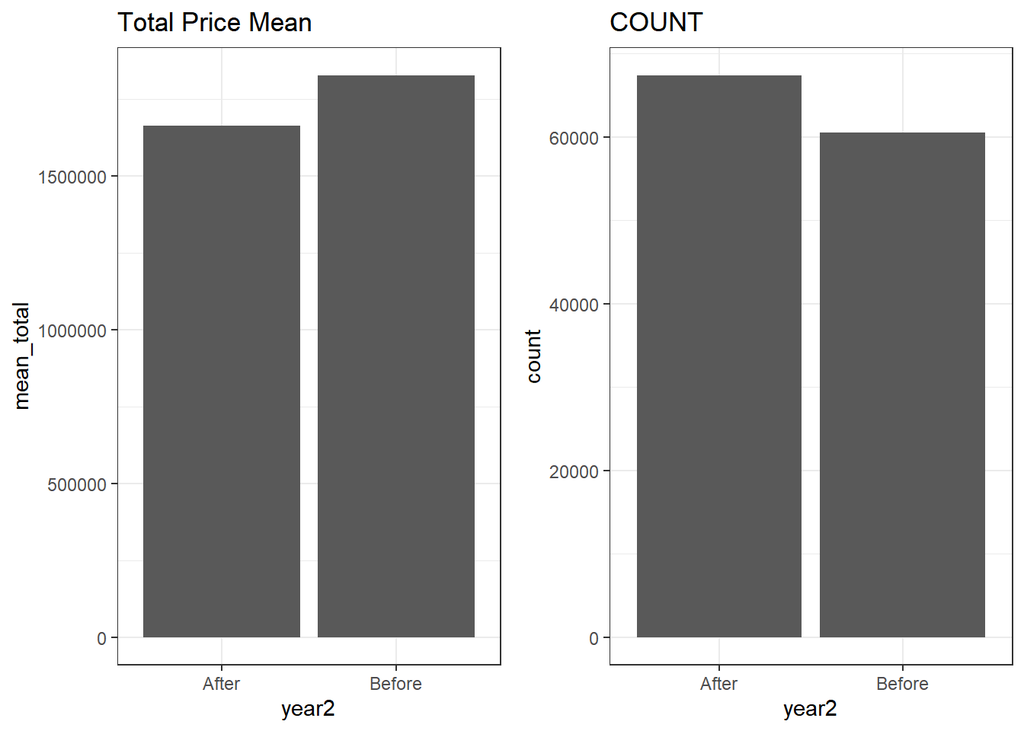

```r
# 차량 색상에 따른 총 수리비용 평균과 분포 개수 확인 #
theme_set(theme_bw())
g1 <- ggplot(data = mean_year, aes(x=year2, y=mean_total)) + geom_col() +
  labs(title="Total Price Mean")
g2 <- ggplot(data = mean_year, aes(x=year2, y=count)) + geom_col() +
  labs(title="COUNT")
grid.arrange(g1, g2, ncol=2)
```

### 2-4-3. 극단값 조정

```r
# 극단값 제거
year_sqrt <- subset(merge_car[merge_car$supercategory_name=="Mid-size car", -1],
                    coating <= 5e+05 & sheet_metal <= 5e+05 & exchange <= 5e+05)

# 정규화 해주기
year_sqrt <- transform(year_sqrt, coating = sqrt(coating + 1))
year_sqrt <- transform(year_sqrt, sheet_metal = sqrt(sheet_metal + 1))
year_sqrt <- transform(year_sqrt, exchange = sqrt(exchange + 1))
year_sqrt <- transform(year_sqrt, total = sqrt(total + 1))

year_sqrt %>% head(7)
```

```
##     coating sheet_metal exchange     total supercategory_name    damage year
## 4  704.6283    512.3485 517.4466 1013.2872       Mid-size car  Breakage 2015
## 5  704.6283    512.3485 517.4466 1013.2872       Mid-size car Scratched 2015
## 6  704.6283    512.3485 517.4466 1013.2872       Mid-size car   Crushed 2015
## 7  409.2689    273.8631 212.1344  536.1912       Mid-size car Scratched 2017
## 8  409.2689    273.8631 212.1344  536.1912       Mid-size car  Breakage 2017
## 9  382.4278    223.6090 170.2968  474.6062       Mid-size car Scratched 2018
## 10 362.2858    193.6517 224.1673  467.9754       Mid-size car Scratched 2017
##     year2
## 4  Before
## 5  Before
## 6  Before
## 7   After
## 8   After
## 9   After
## 10  After
```

```r
table(year_sqrt$year2, year_sqrt$damage)
```

```
##
##          Breakage Crushed Scratched Separated
##   After     10324   11236     27644     14038
##   Before     9472    9937     23945     12680
```

### 2-4-4. 가설 가정에 맞게 데이터 분할

```r
Breakage <- year_sqrt[year_sqrt$damage=="Breakage", c(-5, -7)]
Crushed <- year_sqrt[year_sqrt$damage=="Crushed", c(-5, -7)]
Scratched <- year_sqrt[year_sqrt$damage=="Scratched", c(-5, -7)]
Separated <- year_sqrt[year_sqrt$damage=="Separated", c(-5, -7)]
```

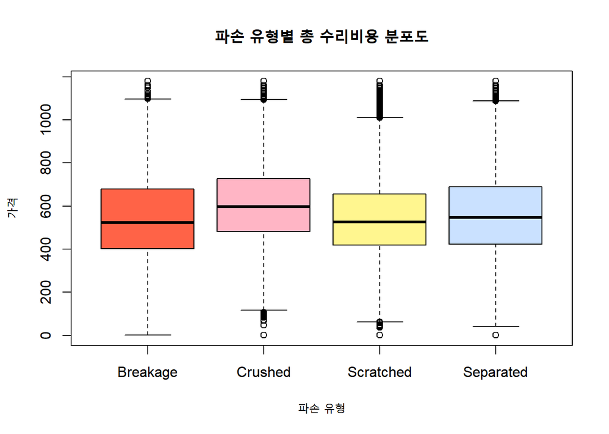

```r
boxplot(Breakage$total, Crushed$total, Scratched$total, Separated$total,
        col=c("Tomato1", "Pink1", "Khaki1", "Light Steel Blue1"), main="파손 유형별 총 수리비용 분포도",
        xlab="파손 유형",ylab="가격", names=c("Breakage","Crushed","Scratched", "Separated"))
```

### 2-4-5. Statistical Test

#### (1) 정규분포 확인

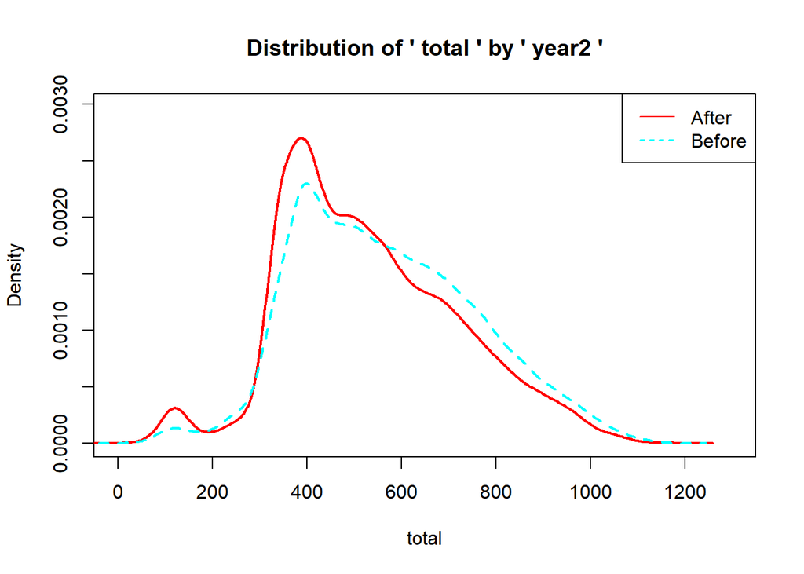

```r
moonBook::densityplot(total~year2, data=Breakage)
```

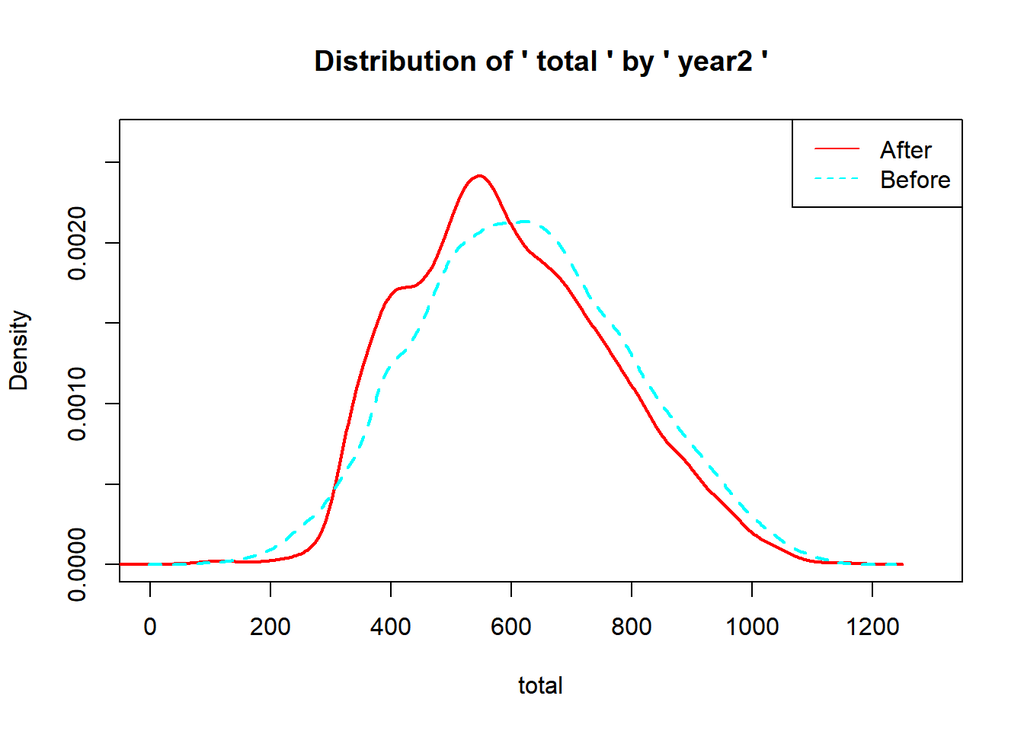

```r
moonBook::densityplot(total~year2, data=Crushed)
```

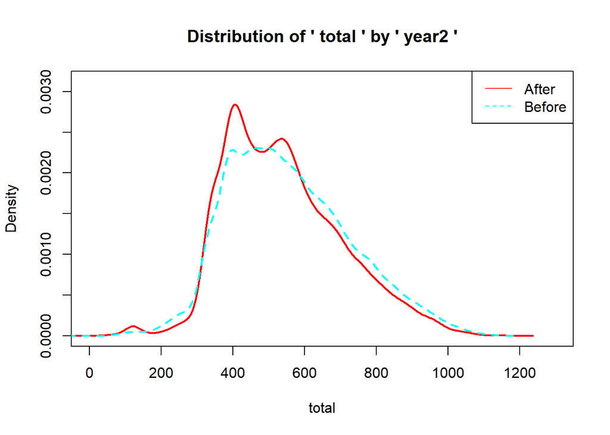

```r
moonBook::densityplot(total~year2, data=Scratched)
```

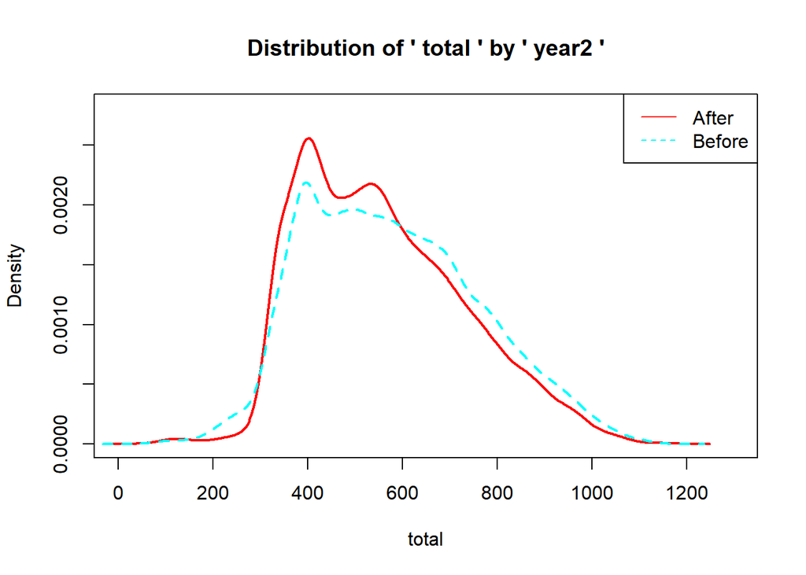

```r
moonBook::densityplot(total~year2, data=Separated)
```

**Mid-size car&Breakage**

```r
ad.test(Breakage$total[Breakage$year2=="Before"])
```

```
##
##  Anderson-Darling normality test
##
## data:  Breakage$total[Breakage$year2 == "Before"]
## A = 56.191, p-value < 2.2e-16
```

```r
ad.test(Breakage$total[Breakage$year2=="After"])
```

```
##
##  Anderson-Darling normality test
##
## data:  Breakage$total[Breakage$year2 == "After"]
## A = 96.761, p-value < 2.2e-16
```

**Mid-size car&Crushed**

```r
ad.test(Crushed$total[Crushed$year2=="Before"])
```

```
##
##  Anderson-Darling normality test
##
## data:  Crushed$total[Crushed$year2 == "Before"]
## A = 8.4878, p-value < 2.2e-16
```

```r
ad.test(Crushed$total[Crushed$year2=="After"])
```

```
##
##  Anderson-Darling normality test
##
## data:  Crushed$total[Crushed$year2 == "After"]
## A = 39.81, p-value < 2.2e-16
```

**Mid-size car&Scratched**

```r
ad.test(Scratched$total[Scratched$year2=="Before"])
```

```
##
##  Anderson-Darling normality test
##
## data:  Scratched$total[Scratched$year2 == "Before"]
## A = 139.42, p-value < 2.2e-16
```

```r
ad.test(Scratched$total[Scratched$year2=="After"])
```

```
##
##  Anderson-Darling normality test
##
## data:  Scratched$total[Scratched$year2 == "After"]
## A = 234.13, p-value < 2.2e-16
```

**Mid-size car&Separated**

```r
ad.test(Separated$total[Separated$year2=="Before"])
```

```
##
##  Anderson-Darling normality test
##
## data:  Separated$total[Separated$year2 == "Before"]
## A = 68.83, p-value < 2.2e-16
```

```r
ad.test(Separated$total[Separated$year2=="After"])
```

```
##
##  Anderson-Darling normality test
##
## data:  Separated$total[Separated$year2 == "After"]
## A = 134.33, p-value < 2.2e-16
```

=> 정규분포를 이루지 않으므로 **kruskal검정**으로 진행  
=> 하지만 표본수가 충분하므로 **중심극한정리**에 의해 정규분포를 이룬다고 가정한 상태에서도 진행

#### (2) 등분산 확인

```r
bartlett.test(total~year2, data=Breakage)
```

```
##
##  Bartlett test of homogeneity of variances
##
## data:  total by year2
## Bartlett's K-squared = 4.2536, df = 1, p-value = 0.03917
```

```r
bartlett.test(total~year2, data=Crushed)
```

```
##
##  Bartlett test of homogeneity of variances
##
## data:  total by year2
## Bartlett's K-squared = 28.646, df = 1, p-value = 8.689e-08
```

```r
bartlett.test(total~year2, data=Scratched)
```

```
##
##  Bartlett test of homogeneity of variances
##
## data:  total by year2
## Bartlett's K-squared = 71.349, df = 1, p-value < 2.2e-16
```

```r
bartlett.test(total~year2, data=Separated)
```

```
##
##  Bartlett test of homogeneity of variances
##
## data:  total by year2
## Bartlett's K-squared = 47.573, df = 1, p-value = 5.3e-12
```

=> 등분산을 이루지 않는다.

#### (3) T-test

**정규분포라 가정**

```r
t.test(total~year2, data=Breakage, alt="two.sided", var.equal=F)
```

```
##
##  Welch Two Sample t-test
##
## data:  total by year2
## t = -12.933, df = 19570, p-value < 2.2e-16
## alternative hypothesis: true difference in means between group After and group Before is not equal to 0
## 95 percent confidence interval:
##  -39.72351 -29.26757
## sample estimates:
##  mean in group After mean in group Before
##             533.1066             567.6022
```

```r
t.test(total~year2, data=Crushed, alt="two.sided", var.equal=F)
```

```
##
##  Welch Two Sample t-test
##
## data:  total by year2
## t = -10.262, df = 20544, p-value < 2.2e-16
## alternative hypothesis: true difference in means between group After and group Before is not equal to 0
## 95 percent confidence interval:
##  -29.03120 -19.71954
## sample estimates:
##  mean in group After mean in group Before
##             597.0835             621.4588
```

```r
t.test(total~year2, data=Scratched, alt="two.sided", var.equal=F)
```

```
##
##  Welch Two Sample t-test
##
## data:  total by year2
## t = -11.954, df = 49677, p-value < 2.2e-16
## alternative hypothesis: true difference in means between group After and group Before is not equal to 0
## 95 percent confidence interval:
##  -20.57396 -14.77781
## sample estimates:
##  mean in group After mean in group Before
##             539.2262             556.9020
```

```r
t.test(total~year2, data=Separated, alt="two.sided", var.equal=F)
```

```
##
##  Welch Two Sample t-test
##
## data:  total by year2
## t = -9.1954, df = 26040, p-value < 2.2e-16
## alternative hypothesis: true difference in means between group After and group Before is not equal to 0
## 95 percent confidence interval:
##  -24.21694 -15.70691
## sample estimates:
##  mean in group After mean in group Before
##             558.1515             578.1134
```

**정규분포가 아니면**

```r
wilcox.test(Breakage$total[Breakage$year2=="Before"], Breakage$total[Breakage$year2=="After"])
```

```
##
##  Wilcoxon rank sum test with continuity correction
##
## data:  Breakage$total[Breakage$year2 == "Before"] and Breakage$total[Breakage$year2 == "After"]
## W = 54091914, p-value < 2.2e-16
## alternative hypothesis: true location shift is not equal to 0
```

```r
wilcox.test(Crushed$total[Crushed$year2=="Before"], Crushed$total[Crushed$year2=="After"])
```

```
##
##  Wilcoxon rank sum test with continuity correction
##
## data:  Crushed$total[Crushed$year2 == "Before"] and Crushed$total[Crushed$year2 == "After"]
## W = 60662819, p-value < 2.2e-16
## alternative hypothesis: true location shift is not equal to 0
```

```r
wilcox.test(Scratched$total[Scratched$year2=="Before"], Scratched$total[Scratched$year2=="After"])
```

```
##
##  Wilcoxon rank sum test with continuity correction
##
## data:  Scratched$total[Scratched$year2 == "Before"] and Scratched$total[Scratched$year2 == "After"]
## W = 350471207, p-value < 2.2e-16
## alternative hypothesis: true location shift is not equal to 0
```

```r
wilcox.test(Separated$total[Separated$year2=="Before"], Separated$total[Separated$year2=="After"])
```

```
##
##  Wilcoxon rank sum test with continuity correction
##
## data:  Separated$total[Separated$year2 == "Before"] and Separated$total[Separated$year2 == "After"]
## W = 94821714, p-value < 2.2e-16
## alternative hypothesis: true location shift is not equal to 0
```

### **RESULT**

`같은 차종, 같은 파손일 때 차량 연식에 따라 수리비용 차이 존재`

Preview

- 3가지 차종의 비교 과정을 전부 보이면 양이 너무 많아져 중형과 총 수리비용을 갖고서 대표적으로 검정 진행.
- 평균과 최댓값의 차이가 커 50만원 초과 제외 후 제곱근을 통해 수의 크기를 줄여줬지만 정규분포를 이루지 않음.
- 하지만 표본수가 Before(2012 ~ 2016)은 5만개, After(2017 ~ 2021)은 6만개 이상이므로 중심극한정리에 의해 정규분포를 이룬다고 가정한 후 두가지 방법으로 검정 진행(소형과 대형 또한 같음)

**Mid-size car**

| damage | Welch | Wilcoxon |
| --- | --- | --- |
| `Breakage` | < 2.2e-16 | < 2.2e-16 |
| `Crushed` | < 2.2e-16 | < 2.2e-16 |
| `Scratched` | < 2.2e-16 | < 2.2e-16 |
| `Separated` | < 2.2e-16 | < 2.2e-16 |

**Compact car**

| damage | Welch | Wilcoxon |
| --- | --- | --- |
| `Breakage` | < 2.2e-16 | < 2.2e-16 |
| `Crushed` | < 2.2e-16 | < 2.2e-16 |
| `Scratched` | < 2.2e-16 | < 2.2e-16 |
| `Separated` | < 2.2e-16 | < 2.2e-16 |

**Full-size car**

| damage | Welch | Wilcoxon |
| --- | --- | --- |
| `Breakage` | 0.0420600 | 0.0349000 |
| `Crushed` | 0.0001469 | 0.0004865 |
| `Scratched` | 0.0000000 | 0.0000000 |
| `Separated` | 0.0000753 | 0.0000424 |

- 각 차량연식마다 총 수리비용 차이 존재
- 즉, *귀무가설 기각*
- **차량 연식에 따라 수리비용 차이 존재**한다고 할 수 있다.